# Semi-automated correlation of Silurian well-logs across Gotland, Sweden, using Dynamic Time Warping with Barycenter Averaging

Authors

Michiel Arts<sup>1</sup>

Daniel Sopher<sup>2</sup>

Mikael Calner<sup>3</sup>

Mikael Erlström<sup>3</sup>

Rohit Samant<sup>4</sup>

Bradley Cramer<sup>5</sup>

Anne-Christine Da Silva<sup>1</sup>

1 - SEDICLIM lab, Department of Geology, University of Liege, Belgium (michiel.arts@uliege.be)

2.- Geological Survey of Sweden, Dragarbrunnsgatan 77, 75319, Uppsala, Sweden

3.- Department of Geology, Lund University, Sölvegatan 12, SE-223 62 Lund, Sweden

4.- Institute of Geology and Palaeontology, University of Münster, 48149, Münster, Germany

5.- Department of Earth and Environmental Sciences, University of Iowa, Iowa City, Iowa, USA

Published

November 1, 2025

# ABSTRACT

Studies of the Silurian sequence on Gotland have significantly advanced our understanding of Silurian climate dynamics, with much of the research focusing on small outcrops and short cores. Gotland has an extensive network of abandoned oil and gas wells. Most of these include gamma-ray well logs, which have not yet been fully utilised for their stratigraphic value. While the Ordovician succession has been successfully correlated using these well logs, the correlation for the Silurian succession has yet to be fully realised. The present study addresses some limitations of Dynamic Time Warping (DTW) correlations by combining DTW with Barycenter Averaging (DBA). The workflow advances existing DTW/DBA approaches by integrating geologically informed pre-stretching with iterative DBA reference-curve construction; together, this enabled the drawing of geologically coherent and internally consistent correlations across multiple wells. The new workflow enabled semi-automated correlation of Silurian well logs over a ~60 km transect. The resulting correlations refine Gotland’s Silurian subsurface architecture by resolving fifteen stratigraphic units, identifying laterally persistent gamma-ray motifs linked to δ¹³C excursions, and revealing local unconformities. This correlation framework extends surface-mapped stratigraphy and biogeochemical events into the subsurface, clarifying how Silurian δ¹³C excursions are expressed in well-log motifs on a basinal scale. Using Gotland as a case study, our results demonstrate how a DTW/DBA-based workflow can integrate subsurface well-log data to produce coherent stratigraphic correlations, offering a broadly applicable and readily transferable approach for use in other basins.

# INTRODUCTION

The workflow is applied to a dataset of gamma-ray well logs from Gotland, Sweden. The island has long been recognised for its Silurian succession, including major biogeochemical events such as the Ireviken, Mulde, Linde, and Lau events (Jeppsson, 1996; Jeppsson and Calner, 2002; Calner et al., 2004a, 2004b; Calner and Eriksson, 2006a; Eriksson and Calner, 2008; Vandenbroucke et al., 2013; Biebesheimer et al., 2021; Hartke et al., 2021; Erlström et al., 2022). Although outcrops and shallow cores from Gotland have yielded valuable insights into Silurian climate and biosphere dynamics, their stratigraphic thickness is often limited. Indeed, among the Silurian biogeochemical events, only the formations encompassing the Lau Event have been extensively mapped in the shallow subsurface using well logs (Eriksson and Calner, 2008; Erlström et al., 2022). Two of the key wells in this study are the Altajme core/well and the St. Sutarve 2018 well, available in their original high-resolution digital form, unlike the rest of the dataset, which consists of digitised records. The Altajme core/well offers one of the highest-resolution δ13Ccarb records of the Silurian (Biebesheimer et al., 2021; Hartke et al., 2021; Stolfus et al., 2023), encompassing both the Ireviken and Mulde events. Integrating this core with gamma ray logs from Gotland enables a regional contextualization. The St. Sutarve-2018 well is central in the geological framework of the subsurface of Southern Gotland (Erlström et al., 2022). Placing this well within a broader regional context will enable a more refined understanding of the geological evolution of Gotland. The implemented workflow will improve stratigraphic correlations across a transect of ~60 kilometres, linking surface and subsurface data, but also establishes a new avenue for the application of Dynamic Time Warping in stratigraphic studies.

# GEOLOGICAL SETTING

The Silurian succession on Gotland was deposited in the Baltic Basin, an intracratonic basin on the palaeocontinent Baltica. During the Silurian, Gotland was located on the northwest flank of the basin, where the water depth increased to the south-east (Baarli et al., 2003). The thickness of the succession increased from circa 250 m in the north to circa 500 m in the south of Gotland, as the basin has a gentle dip of 0.2-0.4 degrees to the southeast. Baltica was located ~10–20° south of the equator during the Silurian, and deposition occurred in a tropical to subtropical setting. The succession is typified by approximately 100 carbonate platforms that prograded from the northeast to southwest during the Silurian (Bjerkéus and Eriksson, 2001; Flodén et al., 2001; Tuuling and Flodén, 2013). These platforms fingers out into in deeper marine depositional settings to the S-SE. The resulting stratigraphy consists of alternating shale or marl and reefal limestone, forming a south-eastward-prograding sequence (Jeppsson, 1996; Calner et al., 2004a, 2004b, 2006; Calner, 2005b; Jeppsson et al., 2006). Due to erosion and the regional dip, progressively younger strata are exposed toward the southeast.

Within individual units, shallow-water facies such as reefal carbonates dominate the northwest, transitioning to deeper-water shales and marls in the southeast. A long-term shallowing trend during the Silurian led to the gradual south-eastward progradation of reefal facies, with shallow reef deposits reaching southeastern Gotland by the Ludfordian (Bjerkéus and Eriksson, 2001; Flodén et al., 2001; Tuuling and Flodén, 2009).

The Silurian strata of Gotland, Sweden, provide an exceptional record of biotic, geochemical, and lithological changes during the Silurian, including the Ireviken, the Mulde, Linde and Lau events (Aldridge et al., 1993; Jeppsson et al., 1995, 2006; Jeppsson and Aldridge, 2000; Calner et al., 2004b, 2004b; Calner and Eriksson, 2006b; Vandenbroucke et al., 2013; Younes et al., 2017; Bowman et al., 2019; Biebesheimer et al., 2021; Hartke et al., 2021; Stolfus et al., 2023; Claussen, 2024). T. These events represent major perturbations to the Earth’s climate system, characterised by extinction episodes, shifts in carbon isotope signatures, and substantial changes in marine ecosystems and depositional environments.

The Ireviken Event is the oldest Silurian event recorded on Gotland and spans the Llandovery-Wenlock boundary interval, and is represented in the Lower Visby to Hangvar. The Ireviken Event is associated with a major extinction event and a positive δ13C excursion (Jeppsson, 1987; Melchin et al., 2005, 2020; Cramer et al., 2010; Rose et al., 2019). The Mulde Event, occurring during the Homerian Stage (~428 Ma),, is preserved in the Fröjel to Klinteberg formations and linked to a minor extinction and a positive δ13C excursion (Samtleben et al., 2000; Calner and Jeppsson, 2003; Calner et al., 2006; Jeppsson et al., 2006). The Linde Event took place in the early Ludfordian and is associated with a minor extinction and a tiny δ13C excursion (Jeppsson and Aldridge, 2000; Claussen, 2024). The Lau Event took place in the late Ludfordian and is associated with a major extinction event and one of the largest δ13C excursions of the entire Phanerozoic (Calner et al., 2006; Calner, 2008; Eriksson and Calner, 2008; Younes et al., 2017; Frýda et al., 2021). The Lau Event is recorded in the Botvide member of the När Formation and the Eke and Burgsvik formations (Jeppsson, 1998; Calner, 2005a; Eriksson and Calner, 2008; Erlström et al., 2022).

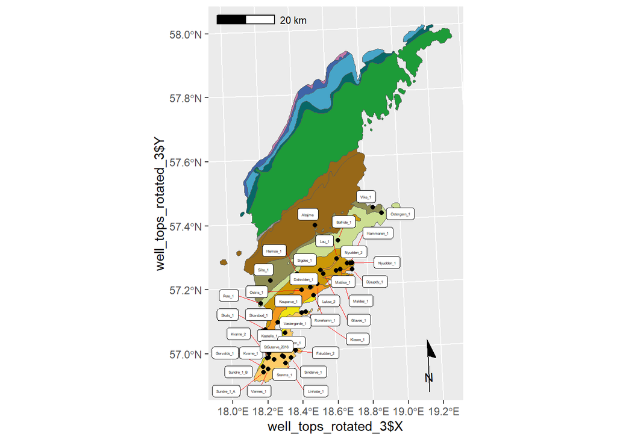

```r
 #Plot some maps ####
well_tops_rotated <- read.csv("https://raw.githubusercontent.com/stratigraphy/DTW-Gotland/main/well_tops_rotated.csv")

well_tops_rotated_3  <- well_tops_rotated
GROTLLINGBO_2 <- c(1660138,6335746,"Grotlingbo_2",rep(1,6))
GROTLLINGBO_1 <- c(1660000,6335550,"Grotlingbo_1",rep(1,6))
GROTLLINGBO <- rbind(GROTLLINGBO_1,GROTLLINGBO_2)
#GROTLLINGBO <- as.data.frame(GROTLLINGBO)
colnames(GROTLLINGBO) <- colnames(well_tops_rotated_3)
well_tops_rotated_3 <- rbind(well_tops_rotated_3,GROTLLINGBO)
well_tops_rotated_3[,1] <- as.numeric(well_tops_rotated_3[,1])
well_tops_rotated_3[,2] <- as.numeric(well_tops_rotated_3[,2])

exclude_wells <- c(
  "Skaggs_1",
  "Sanda_1",
  "Rings_1",
  "Grotlingbo_2",
  "Grotlingbo_1",
  "Grotlingbo_2_Res"
)

# Remove excluded wells
well_tops_rotated_3 <- well_tops_rotated_3[!well_tops_rotated_3$Well %in% exclude_wells, ]

#load a shapefile
#shapename <- st_read('D:/Phd/documents/Altajme/DTW_paper/well_logs/SI_4_logs_used/maps')
#local_path <- "DTW_Gotland_Local/SI_4_logs_used/maps/gotland_wells.shp" # Replace 'gotland_wells.shp' with the actual shapefile name

# 3. READ THE SHAPEFILE
#shapename <- st_read(local_path)


library(sf)
library(ggrepel)
library(ggspatial)
library(rnaturalearth)

# 1. Define the necessary files and their base URL
base_url <- "https://raw.githubusercontent.com/stratigraphy/DTW-Gotland/main/SI_4_logs_used/maps/gotland_geology_2"
extensions <- c(".shp", ".shx", ".dbf", ".prj", ".cpg")

# 2. Create a temporary directory to save the files
temp_dir <- tempdir()
local_shp_path <- file.path(temp_dir, "gotland_geology_2.shp")

# 3. Download each component file
for (ext in extensions) {
  file_url <- paste0(base_url, ext)
  local_file_path <- file.path(temp_dir, paste0("gotland_geology_2", ext))

  # Use download.file to fetch the raw file content
  # mode="wb" (write binary) is crucial for non-text files like .shp and .dbf
  download.file(url = file_url, destfile = local_file_path, mode = "wb")
}

# 4. Read the shapefile from the local temporary directory
# st_read now sees all related files locally, which avoids the GDAL/HTTPS issues.

shapename <- st_read(local_shp_path,quiet=TRUE)

Visby <- shapename[shapename$id == 1, ]
Hogklint <- shapename[shapename$id == 2, ]
Tofta <- shapename[shapename$id == 3, ]
Hangvar <- shapename[shapename$id == 4, ]
Slite <- shapename[shapename$id == 5, ]
Frojel <- shapename[shapename$id == 6, ]
Halla <- shapename[shapename$id == 7, ]
L_Hemse <- shapename[shapename$id == 8, ]
Etelheim <- shapename[shapename$id == 9, ]
Klinteberg <- shapename[shapename$id == 10, ]
Nar <- shapename[shapename$id == 11, ]
Eke <- shapename[shapename$id == 12, ]
Brugsvik <- shapename[shapename$id == 13, ]
Hamra <- shapename[shapename$id == 14, ]
Visby$id <- c("Visby Fm")

#plot the geological map of Gotland

pl <- ggplot() +
  geom_sf(data = shapename) +
  coord_sf(default_crs = sf::st_crs(x = 2400), clip = "off")
pl + geom_sf(data = Visby,
             fill  = rgb(195, 121, 170, 255, maxColorValue = 255)) +
  geom_sf(data = Hogklint,
          fill  = rgb(63, 100, 168, 255, maxColorValue = 255)) +
  geom_sf(data = Tofta,
          fill  = rgb(71, 165, 201, 255, maxColorValue = 255)) +
  geom_sf(data = Hangvar, fill  = "#076766ff") +
  geom_sf(data = Slite, fill  = "#1d9b38ff") +
  geom_sf(data = Frojel, fill  = "#999999ff") +
  geom_sf(data = Halla, fill  = "#976818ff") +
  geom_sf(data = L_Hemse, fill  = "#976818ff") +
  geom_sf(data = Etelheim, fill  = "#8f8d54ff") +
  geom_sf(data = Klinteberg, fill  = "#ccde92ff") +
  geom_sf(data = Nar, fill  = "#cb9807ff") +
  geom_sf(data = Eke, fill  = "#f4981dff") +
  geom_sf(data = Brugsvik, fill  = "#f1e513ff") +
  geom_sf(data = Hamra, fill  = "#fdcc68ff") +
  geom_point(aes(x = well_tops_rotated_3$X, y = well_tops_rotated_3$Y))+
  geom_label_repel(
    aes(x = well_tops_rotated_3[, 1], y = well_tops_rotated_3[, 2], label = well_tops_rotated_3[, 3]),
    box.padding   = 0.2,
    point.padding = 0.2,
    size = 1,
    max.overlaps = getOption("ggrepel.max.overlaps", default = 50),
    segment.color = 'red',
    segment.size = 0.1,   # ensure segment line is visible
    segment.alpha = 1     # ensure it's not transparent
  ) + annotation_scale(location = "tl") +
  annotation_north_arrow(location = "br",
                         which_north = "true",
                         style = north_arrow_minimal())
```

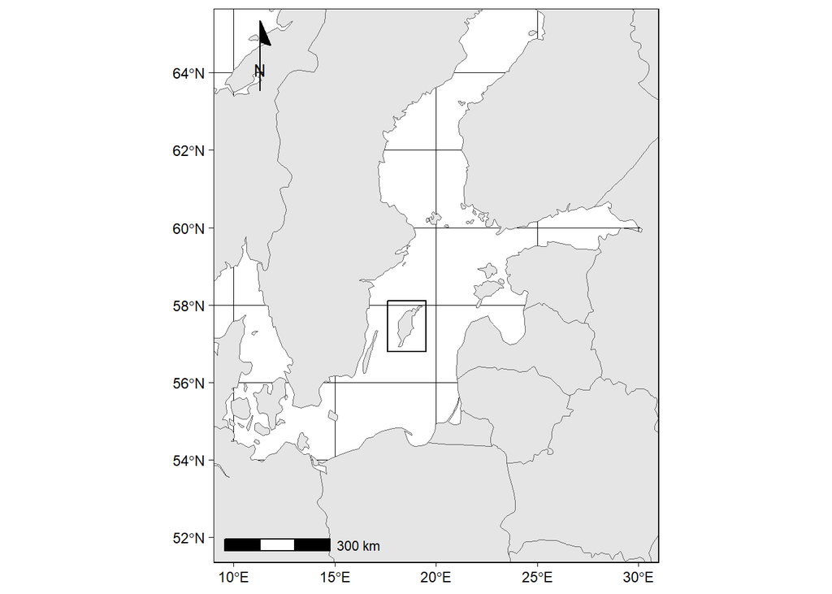

Figure 1B. zoomout map of the study area

```r
#plot regional overview map

europe <- ne_countries(
  continent = "Europe",
  scale = 'medium',
  type = 'map_units',
  returnclass = 'sf'
)

# your_map <- ggplot(europe) +
#   geom_sf() +
#   xlim(c(15, 30)) +
#   ylim(c(50, 62)) +
#   theme_linedraw() + geom_rect(
#     aes(
#       xmin = 17.6,
#       xmax = 19.5,
#       ymin = 56.8,
#       ymax = 58.1
#     ),
#     fill = "NA",
#     col = "black"
#   ) + annotation_scale(location = "bl") +
#   annotation_north_arrow(location = "tl",
#                          which_north = "true",
#                          style = north_arrow_minimal())
#
# your_map


your_map <- ggplot(europe) +
  geom_sf() +
  xlim(c(10, 30)) +
  ylim(c(52, 65)) +
  theme_linedraw() + geom_rect(
    aes(
      xmin = 17.6,
      xmax = 19.5,
      ymin = 56.8,
      ymax = 58.1
    ),
    fill = "NA",
    col = "black"
  ) + annotation_scale(location = "bl") +
  annotation_north_arrow(location = "tl",
                         which_north = "true",
                         style = north_arrow_minimal())

your_map
```

# MATERIALS AND METHODS

This study utilises a total of thirty-eight gamma-ray well logs from Gotland (see Figure 1 and SI.1), several of which have been published (Sopher et al., 2016; Erlström and Sopher, 2019; Levendal et al., 2019; Erlström et al., 2022).The Altajme and St. Sutarve 2018 wells are available in original high-resolution digital form, while the rest belong to the legacy Oljeprospektering AB (OPAB) dataset managed by the Swedish Geological Survey (SGU), originally acquired as analogue paper logs by Oljeprospektering AB between 1960 and 1990; SGU has since digitised a subset of these. Missing or incomplete logs were manually digitised for this study using the Log-Evolve™ software (see SI.1). The wells sampled in this study represent more distal shelfal successions rather than shallow reefal carbonates (see Figure 1 and geological setting), making them especially suitable for dynamic time warping (DTW) since they offer greater continuity and completeness.

The wells sampled in this study represent more distal shelfal successions rather than shallow reefal carbonates (see Figure 1 and geological setting), making them especially suitable for dynamic time warping (DTW) since they offer greater continuity and completeness. To compare surface geology with subsurface gamma ray records, surface maps from Manten (1971) and Calner et al. (2004a) were digitised in QGIS and integrated with literature data. Gamma-ray logs, the primary data type used, reflect natural radiation from Potassium-40, Uranium-238, and Thorium-232 in surrounding rocks (Ellis and Singer, 2007). Since spectral gamma data are unavailable for Gotland, interpretations focus on relative changes in log motifs. The logs have a vertical resolution of about 0.15 to 0.3 meters (Ellis and Singer, 2007). The limited resolution, combined with the inclusion of legacy data, restricts the ability to correlate on a bed-by-bed basis. As such, we will focus on general patterns, inflexion points, and prominent metre-scale peaks and troughs.

One aim of this study is to present a quasi-automated workflow for well-log correlation using the Dynamic Time Warping (DTW) algorithm combined with Barycenter Averaging (DBA). Rather than redeveloping existing methods, this study integrates off-the-shelf R functions into a practical workflow for well-log correlation. The use of established and optimised R packages ensures computational efficiency and reproducibility. In particular, the dtwclust package (Sardá-Espinosa, 2019) provides a robust implementation of the DBA algorithm, which is multi-threaded by default and allows rapid computation of the regional reference curve, typically within minutes. Intermediate data processing steps, such as Taner filtering and LOWESS regression, were performed using functions from the astrochron package (Meyers, 2019). For readers seeking a detailed technical background on the underlying algorithms, we refer to the comprehensive discussions in Sardá-Espinosa (2019) and Meyers (2019). To promote transparency and reproducibility, the full R code implementation is provided in Supplementary Information S3, with an accompanying R Quarto and HTML versions available at https://github.com/stratigraphy/DTW-Gotland, which include step-by-step explanations of each stage of the workflow.

Before the analysis, all gamma-ray logs were normalised to a scale of -1 to 1 to allow for a consistent cross-well comparison and to remove any differences in scaling in values due to the use of different gamma-ray well-logging tools. The well-logs were pre-stretched to a common depth scale, a technique often referred to as placing data in “relative geological time”Sylvester (2023) or “target depth” in the nomenclature presented by Hay et al. (2019). DTW-based studies typically apply this concept to close loops and correct errors after DTW correlations have been conducted (De Bruin et al., 2007; Lomask et al., 2009; Qayyum et al., 2015; Wu et al., 2022; Sylvester, 2023).

Pre-stretching offers a clear advantage, as DTW compares patterns within time-series data and, without accounting for thickness variations, stratigraphically equivalent features may misalign. The pre-stretching was guided by six manually selected tie points corresponding to key stratigraphic features (see Figure 2). The pre-stretching using the tie points acts as a (soft) constraint on the stratigraphic framework, since subsequent DTW runs within the DBA modelling run can still redraw correlation paths based on signal similarity. In this way, geological expertise is integrated without overriding the algorithm’s capacity for objective, data-driven alignment. The approach used is particularly valuable in intervals where correlation confidence is variable rather than absolute. The well logs were pre-stretched to the average observed thickness between the two tie points in the set of wells. Logs were stretched to the average thickness observed between tie points. The Altajme and Vike-1 wells were excluded from the average thickness calculation because their upper intervals are affected by a prograding reefal system during the Mulde Event (Biebesheimer et al., 2021).

Tie point set (1) marks a positive gamma-ray inflexion corresponding to the base of the Silurian (Sopher et al., 2016; Erlström and Sopher, 2019; Erlström et al., 2022). Set (2) aligns with a negative inflexion linked to the S2–S3 sequence boundary in the Baltic Basin and roughly coincides with the onset of the Ireviken Event (see Figure 2) Lazauskiene et al. (2003); (Hartke et al., 2021; Erlström et al., 2022). Set (3) corresponds to a gamma-ray trough at the base of the Mulde Event (see Figure 2 and SI.2.) (Calner et al., 2006; Erlström et al., 2022). Despite differing log expressions, this tie point could be identified in both the Altajme and Grötlingbo-1 wells, aided by the observation of the Mulde δ13Ccarb excursion in both records (see SI.2) (Calner et al., 2006). Set (4) is a positive gamma-ray inflexion that marks the approximate termination of the Mulde Event, which again could be identified with the help of the records from the Altajme and the more distal Grötlingbo-1 wells/cores (Calner et al., 2006). Set (5) is a minor gamma-ray peak traceable across most wells (see Figure 2). Set (6) is a negative inflexion in the gamma-ray log, which marks the boundary between the Hemse Group and Eke Formation (Eriksson and Calner, 2008; Erlström et al., 2022). Due to the regional dip and erosion, increasingly thicker intervals of younger Silurian strata are missing toward the northwest of Gotland (see Geological setting). As a result, one or more stratigraphic tie-points may be absent in that direction. The missing tie points prevent stretching to a common depth scale. In such cases, missing intervals were filled using a median curve derived from the complete well logs.

The DBA process reduces the influence of outlier logs or local anomalies while preserving regionally consistent stratigraphic patterns. The resulting barycentric curve represents an optimised, consensus-based gamma-ray reference profile that captures the most stable and correlateable lithological features across the entire set of well-logs. By averaging in the DTW space, DBA yields a more geologically meaningful composite curve than conventional stacking or depth-normalised averaging, particularly in successions where sedimentation rates and compaction histories vary among wells.

Like with most DTW-based alignment techniques, the DBA process can introduce blocky or spiky artefacts due to its tendency to over-sample flat regions. These artefacts were removed using a Taner bandpass filter, followed by a LOWESS regression to preserve local extremes while removing broader trends (Meyers, 2019). From the resulting smoothed and detrended reference curve, the 150 largest-amplitude peaks were selected as regional correlation points. The number itself is not arbitrary, since it corresponds to the maximum number of distinct, geologically meaningful peaks identifiable in the reference curve. The DTW algorithm was then applied between the reference curve and each of the thirty-eight (pre-stretched) well logs, allowing the regional tie points to be transposed onto the individual logs. These tie points serve as the basis for the drawing of correlation lines across all wells, supporting a detailed subsurface interpretation.

Load in the data

```r
#written by Michiel Arts michiel.arts@stratigraphy.eu
#Ensure that the right working directories are set to allow one to load the right files!!!
#load the R packages ####
library(ggplot2)
library(astrochron)
library(dtw)
library(plotly)
library(rlist)
library(data.table)
library(WaverideR)
library(dtwclust)
library(ggrepel)
library(dplyr)
library(matrixStats)
library(sf)
library(colorspace)
library(ggspatial)
library(rnaturalearth)
library(DescTools)
library(matrixStats)
library(jsonlite)
library(gh)
library(gert)


all_txt_data <- list()


# Clone the repo to a temp directory

Sys.setenv(GITHUB_PAT = "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")
pat <- Sys.getenv("GITHUB_PAT")




repo_path <- tempfile("DTW-Gotland_")
git_clone("git@github.com:stratigraphy/DTW-Gotland.git", repo_path)

all_txt_data <- list()


# 3. Modify the recursive function to include the Authorization header
list_github_txt_files <- function(api_url, token) {
  # Use an Authorization header for authentication
  response <- httr::GET(
    url = api_url,
    httr::add_headers(
      Authorization = paste("token", token),
      Accept = "application/vnd.github.v3+json"
    )
  )

  # Check for HTTP errors (like 403 Forbidden)
  if (httr::http_error(response)) {
    stop(paste("GitHub API Error:", httr::status_code(response), httr::content(response, "text", encoding = "UTF-8")))
  }

  # Parse the JSON content
  data <- jsonlite::fromJSON(httr::content(response, "text", encoding = "UTF-8"), flatten = TRUE)

  txt_files <- character(0)

  for (i in seq_along(data$type)) {
    if (data$type[i] == "file" && grepl("\\.txt$", data$name[i], ignore.case = TRUE)) {
      # The 'download_url' is directly provided by the API response
      txt_files <- c(txt_files, data$download_url[i])
    } else if (data$type[i] == "dir") {
      # The API response already contains the 'url' for the subdirectory
      subdir_url <- data$url[i]
      txt_files <- c(txt_files, list_github_txt_files(subdir_url, token))
    }
  }
  return(txt_files)
}


# Top-level directory API URL
root_api <- "https://api.github.com/repos/stratigraphy/DTW-Gotland/contents/SI_4_logs_used"

# You'll need to load the required libraries
if (!requireNamespace("httr", quietly = TRUE)) install.packages("httr")
if (!requireNamespace("jsonlite", quietly = TRUE)) install.packages("jsonlite")
library(httr)
library(jsonlite)

# Call the function with the root URL and the PAT
txt_urls <- list_github_txt_files(root_api, pat)

#txt_urls[1:5]  # preview first few

# Read each text file into a named list
well_logs_list <- list()

for (file_url in txt_urls) {
  first_line <- tryCatch(readLines(file_url, n = 1), error = function(e) return(NA))
  if (is.na(first_line)) next

  has_header <- grepl("[A-Za-z]", first_line)

  df <- tryCatch({
    if (has_header) {
      read.table(file_url, header = TRUE, sep = "", stringsAsFactors = FALSE)
    } else {
      df <- read.table(file_url, header = FALSE, sep = "", stringsAsFactors = FALSE)
      colnames(df)[1:2] <- c("DEPTH", "GR")
      df
    }
  }, error = function(e) NULL)

  if (!is.null(df)) {
    file_name <- tools::file_path_sans_ext(basename(file_url))
    well_logs_list[[file_name]] <- df
    list_name <- paste0(file_name)
    all_txt_data[[list_name]] <- df
  }
}

# Check results
#sort(names(all_txt_data))

# rename to well-log list
well_logs_list <- all_txt_data

for (file_url in txt_urls) {
  first_line <- tryCatch(readLines(file_url, n = 1), error = function(e) return(NA))
  if (is.na(first_line)) next

  has_header <- grepl("[A-Za-z]", first_line)

  df <- tryCatch({
    if (has_header) {
      read.table(file_url, header = TRUE, sep = "", stringsAsFactors = FALSE)
    } else {
      df <- read.table(file_url, header = FALSE, sep = "", stringsAsFactors = FALSE)
      colnames(df)[1:2] <- c("DEPTH", "GR")
      df
    }
  }, error = function(e) NULL)

  if (!is.null(df)) {
    file_name <- tools::file_path_sans_ext(basename(file_url))
    well_logs_list[[file_name]] <- df
    list_name <- paste0(file_name)
    all_txt_data[[list_name]] <- df
  }
}

# rename to well-log list
well_logs_list <- all_txt_data

#remove the _GR. extension from the file names in the list of well-logs
well_logs_list <- all_txt_data
for (col in 1:length(well_logs_list)) {
  names(well_logs_list)[[col]] <-
    gsub("_GR.*", "", names(well_logs_list)[[col]])
}

well_logs_list <- well_logs_list[order(names(well_logs_list))]
```

Load the d13Ccarb record of the Altajme core

```r
#load the d13C record of the Altajme core ####

Altamje_d13C <- read.csv("https://raw.githubusercontent.com/stratigraphy/DTW-Gotland/main/Altamje_d13C.csv")

Altamje_d13C <- demean(Altamje_d13C, genplot = F, verbose = F)
Altamje_d13C[, 2]  <- Altamje_d13C[, 2] - min(Altamje_d13C[, 2])
Altamje_d13C[, 2]  <- Altamje_d13C[, 2] / max(Altamje_d13C[, 2])
Altamje_d13C <- iso(Altamje_d13C,
                    xmax = 324,
                    xmin = 0,
                    genplot = FALSE,verbose = F)
```

Load the well tops which are the initial correlation lines drawn into the correlation using existing stratigraphic knowledge.

```r
well_tops_rotated <- read.csv("https://raw.githubusercontent.com/stratigraphy/DTW-Gotland/main/well_tops_rotated.csv")

exclude_wells <- c("Skaggs_1", "Sanda_1", "Rings_1", "Grotlingbo_2")
wells_incl <- well_tops_rotated[!well_tops_rotated$Well %in% exclude_wells, ]
```

Calculate the thickness of the beds in-between the initial correlation lines/points.

```r
readjusted_matrix <- wells_incl

readjusted_matrix_means <-
  matrix(
    data = NA,
    nrow = nrow(readjusted_matrix),
    ncol = (ncol(readjusted_matrix) - 4)
  )

# fill the matrix with thickness of the beds
for (i in 4:(ncol(readjusted_matrix) - 1)) {
  a <- (i - 3)
  top <- as.matrix(unlist(readjusted_matrix[i + 1]))
  top[is.na(top)] <- 0
  bottom <- as.matrix(unlist(readjusted_matrix[i]))
  readjusted_matrix_means[, a] <- bottom - top


}


readjusted_matrix_means <- as.data.frame(readjusted_matrix_means)
readjusted_matrix_means$top <-
  as.matrix(unlist(readjusted_matrix[, (ncol(readjusted_matrix))]))
colnames(readjusted_matrix_means) <-
  colnames(readjusted_matrix[, 4:ncol(readjusted_matrix)])
```

Calculate how much the beds in-between the initial correlation lines/points need to stretched in the pre-stretching.

```r
#calculate the strechfactor fot the beds
strech_fact <-
  1 / ((readjusted_matrix_means / matrix(
    rep(
      colMaxs(as.matrix(readjusted_matrix_means[c(2:37),]), na.rm = TRUE),
      each = nrow(readjusted_matrix_means)
    ),
    nrow = nrow(readjusted_matrix_means),
    ncol = ncol(readjusted_matrix_means)
  )))

strech_fact <- as.data.frame(strech_fact)
strech_fact <- cbind(readjusted_matrix[, 3], strech_fact)
colnames(strech_fact) <-
  names(readjusted_matrix[, 3:ncol(readjusted_matrix)])

well_padded <- readjusted_matrix
well_padded <- as.data.frame(as.matrix(well_padded))
well_padded <- well_padded[, 4:ncol(well_padded)]
well_padded <-
  lapply(well_padded, function(well_padded)
    as.numeric(as.character(well_padded)))
well_padded <- as.data.frame(well_padded)
colmaxs <- colMeans(as.matrix(well_padded), na.rm = TRUE)


well_padded$top_surface <-
  well_padded[, ncol(well_padded)] - colmaxs[length(colmaxs)]
base_data <- well_padded[, 1] + 20
well_padded <- cbind(base_data, well_padded)
well_padded <- cbind(strech_fact[, 1], well_padded)
colnames(well_padded)[1] <- c("well")

maxvals <-
  colMeans(as.matrix(readjusted_matrix_means), na.rm = TRUE)
maxvals <- c(20, maxvals)
maxvals <- round((maxvals / 0.1), 0)
maxvals_depth <- maxvals

for (i in ((length(maxvals) - 1):1)) {
  maxvals_depth[i] <- maxvals_depth[i] + maxvals_depth[i + 1]
}
maxvals_depth[length(maxvals_depth) + 1] <- 0
```

Conduct the pre-stretching.

```r
# stretch the data to a common depth scale using the mean thickness
prestreched_data <- list()

for (hln in 1:nrow(well_padded)) {
  norm_log <- matrix(ncol = 3)
  norm_log <- as.data.frame(norm_log[-1, ])
  colnames(norm_log) <- c("norm_depth", "proxy", "depth_old")
  index <- grep(well_padded[hln, 1], names(well_logs_list), ignore.case = TRUE)
  well_1 <- well_logs_list[[index[1]]]

  suppressWarnings(
    suppressMessages(
      capture.output(
        well_1 <- sortNave(well_1, genplot = FALSE, verbose = FALSE),
        file = NULL
      )
    )
  )


  well_1 <- linterp(well_1, 0.1, genplot = F, verbose = F)
  well_1 <- demean(well_1, genplot = F, verbose = F)
  well_1[, 2]  <- well_1[, 2] - min(well_1[, 2])
  well_1[, 2]  <- well_1[, 2] / max(well_1[, 2])
  well_1 <- demean(well_1, genplot = F, verbose = F)

for (i in 1:(length(maxvals_depth) - 1)) {
    well_1_sel <- well_1[well_1[, 1] < well_padded[hln, i + 1], ]

    well_1_sel <-
      well_1_sel[well_1_sel[, 1] > well_padded[hln, i + 2], ]
    new_depths <-
      seq(from = maxvals_depth[i + 1] + 1,
          to = maxvals_depth[i],
          by = 1)

    if (nrow(well_1_sel) == 0  | any(is.na(well_1_sel))) {
      pad_NA <- rep(NA, times = length(new_depths))
      seq_1 <- cbind(new_depths, pad_NA, pad_NA)

    } else{
      app <-
        approx(
          x = well_1_sel[, 1],
          y = well_1_sel[, 2],
          method = "linear",
          n = length(new_depths),
          rule = 1,
          f = 0,
          ties = mean,
          na.rm = TRUE
        )
      seq_1 <- cbind(new_depths, app$y, app$x)
    }

    colnames(seq_1) <- c("norm_depth", "proxy", "depth_old")
    norm_log <- rbind(norm_log, seq_1)

  }

  norm_log <- norm_log[order(norm_log[, 1], decreasing = FALSE), ]
  prestreched_data <- list.append(prestreched_data, norm_log)

}

#if you want to save or load the data
#saveRDS(prestreched_data, file = "prestreched_data.rds")
#prestreched_data <- readRDS("prestreched_data.rds")

#order the data according to the base of the Silurian
prestreched_data <-
  prestreched_data[order(well_padded[, 3], decreasing = T)]
well_padded_ord <- well_padded[order(well_padded[, 3], decreasing = T),]

prestreched_data <- prestreched_data[c(1:34,37,38,35,36)]
well_padded_ord <- well_padded_ord[c(1:34,37,38,35,36),]

names(prestreched_data) <- well_padded_ord[,1]

#create a new matrix to fill with the pre-stretched data
data <- matrix(data = NA, nrow = nrow(prestreched_data[[1]]))
#prestreched_data
#nrow(prestreched_data[[1]])


#fill the matrix with the pre-stretched data which was also normalised (-1 to 1)
for (i in 1:length(prestreched_data)) {
  data_1 <- prestreched_data[[i]]
  data_1 <- data_1[, c(1, 2)]
  data_1[, 2] <- data_1[, 2] - mean(na.omit(data_1[, 2]))
  data_1 <- data_1[, 2]
  data_1 <- data_1 / (max(na.omit(data_1)) - min(na.omit(data_1)))
  data_1 <- data_1 / sd(na.omit(data_1))
  data_1 <- data_1 - mean(na.omit(data_1))
  data_1 <- data_1 / (max(na.omit(data_1)) - min(na.omit(data_1)))
  data_1 <- data_1 - mean(na.omit(data_1))
  data <- cbind(data, data_1)
}
#remove the first empty column
data <- data[, -c(1)]

#create a median curve###
cent <- rowMedians(as.matrix(data), na.rm = TRUE)

#convert the stretched data to a list
data_ls <- as.list(as.data.frame(data))

#pad NA's with the  values of the centroid
for (i in 1:length(data_ls)) {
  data_ls[[i]][is.na(data_ls[[i]])] <- cent[is.na(data_ls[[i]])]
}


exclude_wells <- c("Skaggs_1",
                   "Sanda_1",
                   "Rings_1",
                   "Grotlingbo_2",
                   "Grotlingbo_1",
                   "Grotlingbo_2_Res")

well_logs_list_2 <- well_logs_list[!names(well_logs_list) %in% exclude_wells]
well_tops_rotated_2 <- well_tops_rotated[!well_tops_rotated$Well %in% exclude_wells,]

names_prestretched <- tolower(names(prestreched_data))
names_well_logs <- tolower(names(well_logs_list_2))

# Match names (lowercase) and get index
matched_idx <- match(names_prestretched, names_well_logs)

# Keep only matched and existing entries
valid_idx <- which(!is.na(matched_idx))
matched_order <- matched_idx[valid_idx]

# Reorder well_logs_list_2 to match prestretched_data
well_logs_list_3 <- well_logs_list_2[matched_order]
#well_tops_rotated_2 <- well_tops_rotated_2[matched_order,]


target_order <- names(well_logs_list_3)
well_tops_wells <- well_tops_rotated_2$Well
match_index <- match(toupper(well_tops_wells), toupper(target_order))
sorting_sequence <- order(match_index)
well_tops_rotated_2 <- well_tops_rotated_2[sorting_sequence, ]

# Optional: assign matching names for clarity
names(well_logs_list_3) <- names(prestreched_data)[valid_idx]

for (i in 1:length(well_logs_list_3)) {
  well_1 <- well_logs_list_3[[i]]
  well_1 <- well_1[well_1[, 1] <= max(prestreched_data[[i]][, 3], na.rm = TRUE), ]
  suppressWarnings(
    suppressMessages(
      capture.output(
        well_1 <- sortNave(well_1, genplot = FALSE, verbose = FALSE),
        file = NULL
      )
    )
  )
  well_1 <- linterp(well_1, genplot = FALSE,verbose = F)
  well_1 <- demean(well_1, genplot = F, verbose = F)
  well_1[, 2]  <- well_1[, 2] - min(well_1[, 2])
  well_1[, 2]  <- well_1[, 2] / max(well_1[, 2])
  well_1 <- demean(well_1, genplot = F, verbose = F)
  well_logs_list_3[[i]] <- well_1
}
```

Plot the well-logs pre and post stretching including the corrrelation lines/points.

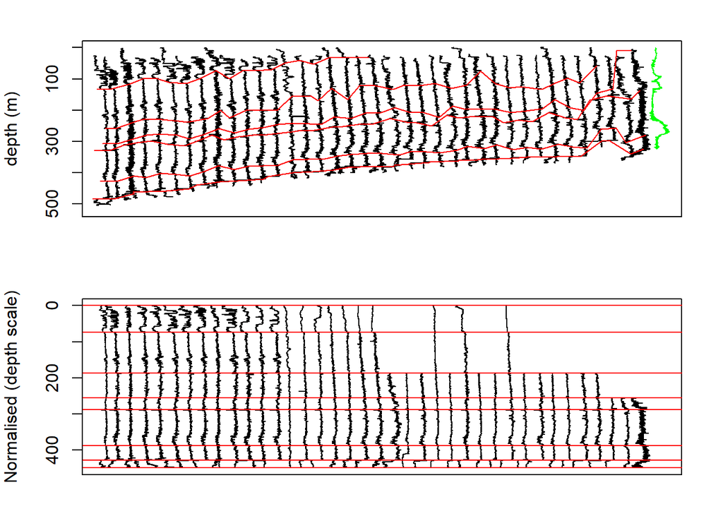

```r
{


  layout.matrix <-
    matrix(c(1:2), nrow = 2, ncol = 1)
  graphics::layout(mat = layout.matrix,
                   heights = c(1),
                   # Heights of the two rows
                   widths = c(1)) # Widths of the two columns
  par(mar = c(2, 4, 2, 2))

  plot(
    well_logs_list_3[[1]][, c(2)],
    y = well_logs_list_3[[1]][, c(1)],
    type = "l",
    xlim = c(0, length(well_logs_list_3) * 0.75),
    ylim = c(520, 0),xaxt="n",ylab="depth (m)",xlab=""
  )

  for (i in 2:length(well_logs_list_3)) {
    lines(x = well_logs_list_3[[i]][, c(2)] + (i * (0.75) - 1),
          y = well_logs_list_3[[i]][, c(1)],
          col = "black")
  }

  #add the d13C record of the Altajme core to the plot
  lines(x = c(Altamje_d13C[, 2] + ((
    length(prestreched_data) * 0.75
  ) - 0.5)),
  y = Altamje_d13C[, 1],
  col = "green")

  y_vals <- well_tops_rotated_2[,4:ncol(well_tops_rotated_2)]
  x_vals <- y_vals
  y_vals

  for (i in 1:ncol(y_vals)) {
    for (j in 1:length(well_logs_list_3)) {

      x_val_well <- (well_logs_list_3[[j]][, c(2)] + (j * (0.75) - 1))
      y_val_well <- (well_logs_list_3[[j]][, c(1)])
      val_well <- cbind(x_val_well, y_val_well)
      val_well <- val_well[complete.cases(val_well), ]
      row_nr <- Closest(val_well[, 2], y_vals[j,i], which = TRUE)
      if (!is.na(row_nr[1])){x_vals[j,i] <- val_well[row_nr[1]]}
    }
    lines(x = x_vals[, i], y = y_vals[, i], col = "red")


  }







  # plot the prestreched data
  plot(
    prestreched_data[[1]][, c(2)],
    prestreched_data[[1]][, c(1)]/10,
    type = "l",
    xlim = c(0, length(data_ls) * 0.75),
    ylim = c(4500/10, 0),xaxt="n",xlab="",ylab="Normalised (depth scale)"
  )
  for (i in 2:length(data_ls)) {
    lines(x = prestreched_data[[i]][, c(2)] + (i * (0.75) - 1),
          y = prestreched_data[[i]][, c(1)]/10,
          col = "black")
  }
  # add the formation/tie-points boundaries
  abline(h = maxvals_depth/10, col = "red")
}
```

# RESULTS

The DBA algorithm produced a regional gamma-ray reference curve based on the thirty-eight gamma-ray logs (Figure 3A), which was then denoised and detrended (Figures 3A and B). From the detrended curve, a hundred and fifty data points with the largest deviations from the mean trendline were identified as key tie-points for basin-scale correlation (Figures 3B and C). Each of the thirty-eight gamma-ray logs was aligned to the reference curve using DTW, enabling the hundred and fifty tie-points to be transposed into individual well logs (see Figure 4). This allowed for the automatic generation of correlation lines between corresponding tie-points (Figure 4A and B). It also allowed the construction of a cross-section along a ~60 km transect from the Sindarve-1 well to the Altajme core/well (Figure 4B). The correlated transect spans depositional settings from shallowest reefal (Altajme) to the deepest marine environment (Sindarve-1), offering a detailed view of lateral stratigraphic variations within the Silurian succession of Gotland.

Run the DBA algorithm to generate the reference curve.

```r
# run the DTW with Barycenter averaging ####

dtw_avg <- DBA(
  data_ls,
  centroid = cent,
  max.iter = 2000L,
  delta = 0.0025,
  trace = TRUE,
  norm = "L2",
  normalize = TRUE,
  step.pattern = dtw::symmetric2,
  error.check = TRUE,
  window.size = 200,
  backtrack = TRUE,
  sqrt.dist = TRUE,
  mv.ver = "by-variable"
)
```

```
    DBA Iteration: 1, 2, 3, 4, 5, 6, 7, 8, 9, 10,
         11, 12, 13, 14, 15, 16, 17, 18, 19, 20,
         21, 22, 23, 24, 25, 26, 27, 28, 29, 30,
         31, 32, 33, 34, 35, 36, 37, 38 - Converged!
```

Denoise and post-process the DBA reference curve and select the 150 tie-points.

```r
#Denoise and post-process the DBA results and select the 150 tie-points ####
a <- cbind(prestreched_data[[1]][1], dtw_avg)

a <- taner(
  a,
  flow = 1 / 30,
  fhigh = 1 / (max(a[1]) * 2),
  roll = 10 ^ 20,
  detrend = FALSE,
  demean = FALSE,genplot=FALSE,verbose=FALSE
)


a_nl <- noLow(a, smooth = 0.075,genplot=FALSE,verbose=FALSE)
a_mx <- max_detect(a_nl, pts = 5)
a_mn <- min_detect(a_nl, pts = 5)


a_pks <- rbind(a_mx, a_mn)
a_pks[, 2] <- abs(a_pks[, 2])

a_pks <- a_pks[order(-a_pks[, 2]), ]

n_tiepoints <- 150

tie_points <- matrix(data = NA, ncol = 3, nrow = n_tiepoints)
tie_points <- as.data.frame(tie_points)
min_offset <- 0.25

for (i in 1:n_tiepoints) {
  tie_points[i, ] <- a_pks[1, ]
  a_pks <- a_pks[-c(1), ]
  vals <- abs(a_pks[, 1] - tie_points[i, 1])
  a_pks <- a_pks[vals > min_offset, ]
}
```

Plot the reference curve and its derived correlation points.

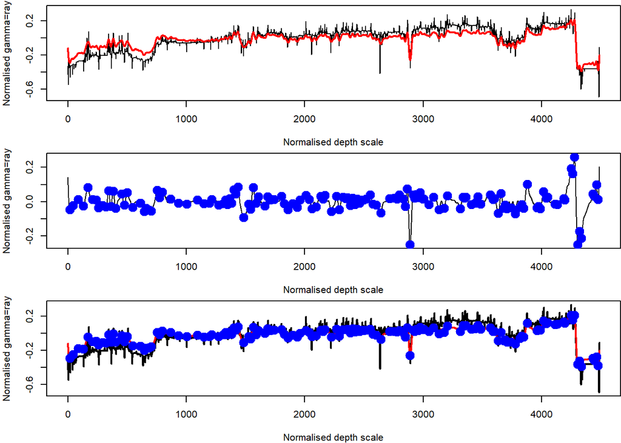

```r
layout.matrix <-
  matrix(c(1:3), nrow = 3, ncol = 1)
graphics::layout(mat = layout.matrix,
                 heights = c(1),
                 # Heights of the two rows
                 widths = c(1)) # Widths of the two columns
par(mar = c(4, 4, 0.5, 0))

plot(
  cbind(prestreched_data[[1]][1], dtw_avg),
  type = "l",
  xlab = "Normalised depth scale",
  ylab = "Normalised gamma=ray"
)
lines(a, col = "red", lwd = 2)

plot(a_nl,
     type = "l",
     xlab = "Normalised depth scale",
     ylab = "Normalised gamma=ray")

points(a_nl[tie_points[, 1], ],
       col = "blue",
       pch = 19,
       cex = 2)

plot(
  cbind(prestreched_data[[1]][1], dtw_avg),
  type = "l",
  lwd = 2,
  xlab = "Normalised depth scale",
  ylab = "Normalised gamma=ray"
)
lines(a, col = "red", lwd = 2)
points(a[tie_points[, 1], ],
       col = "blue",
       pch = 19,
       cex = 2)
```

Re-correlate the wells to the reference curve using DTW.

```r
# re-correlate the wells to the reference curve ####

a_pks <- tie_points
tie_points <- matrix(data = NA, ncol = 1, nrow = n_tiepoints)

for (i  in 1:nrow(tie_points)) {
  row_nr_1 <-
    DescTools::Closest(as.matrix(prestreched_data[[1]][1]), a_pks[i, 1], which = TRUE)
  tie_points[i, 1] <- row_nr_1[1]
}

corr_points <- list()
data_tuned_cor <- list()


for (i in 1:length(data_ls)) {

  x <- taner(
    cbind(seq(1:length(data_ls[[i]])), data_ls[[i]]),
    flow = 1 / 30,
    fhigh = 1 / (max(a[1]) * 2),
    roll = 10 ^ 20,
    detrend = FALSE,
    genplot = FALSE,
    verbose = FALSE
  )

  dtw_basic_1 <- dtw_basic(
    x = x[, 2],
    y = a[, 2],
    norm = "L2",
    normalize = TRUE,
    step.pattern = dtw::symmetric2,
    error.check = TRUE,
    window.size = 200,
    backtrack = TRUE,
    sqrt.dist = TRUE,
    mv.ver = "by-variable"#,
    #open.end = TRUE,
    #open.begin = TRUE
  )


  tie_points_2 <- tie_points
  for (j  in 1:nrow(tie_points)) {
    row_nr_1 <-
      DescTools::Closest(dtw_basic_1[[2]], tie_points[j, 1], which = TRUE)
    tie_points_2[j, 1] <- row_nr_1[1]
  }

  vals <- prestreched_data[[i]][2][dtw_basic_1[[2]][tie_points_2], ]
  depths <-
    prestreched_data[[i]][3][dtw_basic_1[[2]][tie_points_2], ]
  corr_pts <- cbind(depths, vals)

  time_cor <-
    cbind(prestreched_data[[1]][1][dtw_basic_1[[2]][tie_points_2], ], prestreched_data[[1]][1][dtw_basic_1[[3]][tie_points_2], ])

capture.output({
  suppressWarnings(
    suppressMessages({
      time_cor <- sortNave(time_cor[, c(1, 2)], genplot = FALSE, verbose = FALSE)
      time_cor <- sortNave(time_cor[, c(2, 1)], genplot = FALSE, verbose = FALSE)
      time_cor <- sortNave(time_cor[, c(2, 1)], genplot = FALSE, verbose = FALSE)
    })
  )
}, file = NULL)



  data_ls_tuned <-suppressMessages(
  suppressWarnings(
    tune(cbind(prestreched_data[[1]][1], prestreched_data[[i]][2]),
         time_cor,
         genplot = FALSE,verbose=FALSE)))

  data_ls_tuned[, 1] <- data_ls_tuned[, 1] / 10
  #plot(data_ls_tuned,type="l")
  #plot(cbind(prestreched_data[[1]][1], prestreched_data[[i]][2]),type="l")

  data_tuned_cor <- list.append(data_tuned_cor, data_ls_tuned)

  corr_points <- list.append(corr_points, corr_pts)
}
```

Plot the tie-points for between all the wells

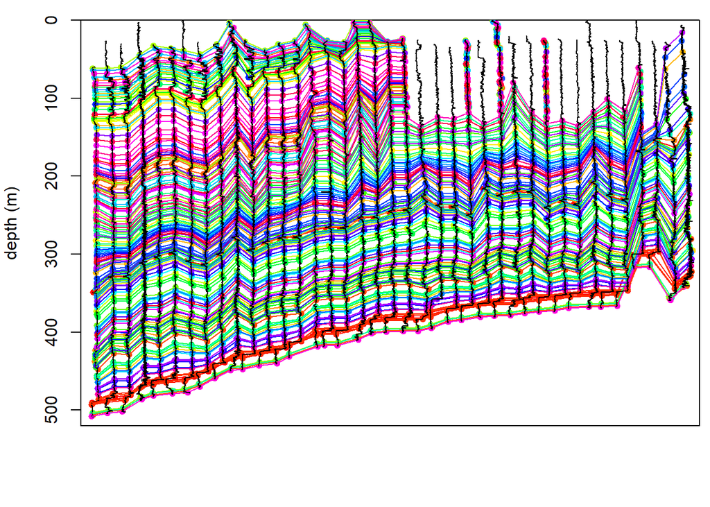

Figure 4A. correlation lines drawn between the correlation points. A. All of the thirty-eight gamma-ray logs with the DBA-derived correlation points and lines. Note that we show the normalised logs, plotted side by side, sorted in order of the depth to the base of the Silurian. The reference well was shifted down by 60 metres.

```r
# plot the tie-points for all the wells ####
colors <- rainbow(n_tiepoints)

layout.matrix <- matrix(1,
                        nrow = 1,
                        ncol = 1,
                        byrow = TRUE)
layout(layout.matrix, heights = c(1), widths = c(1))

par(mar = c(4, 4, 1, 0.5))


plot(
  x = c(-2.2, length(data_tuned_cor) * 1.2),
  y = c(525, 0),
  col = "white",
  xlab = "",
  ylab = "depth (m)",
  xaxt = "n",
  xaxs = "i",
  yaxs = "i",
  ylim = c(520, 0)
)            # Draw empty plot

points(
  y = (a[tie_points, 1] / 10) + prestreched_data[[1]][1, 3],
  x = a[tie_points, 2] - 1 ,
  col = colors,
  pch = 19,
  cex = 0.75
)


lines(a[, 2] - 1, (a[, 1] / 10) + prestreched_data[[1]][1, 3])


for (i in 1:length(prestreched_data)) {
  well_line <- cbind(well_logs_list_3[[i]][1], well_logs_list_3[[i]][2])
  pts <- corr_points[[i]]
  for (j in 1:nrow(pts)) {
    rownr <- DescTools::Closest(well_line[, 1], pts[j, 1], which = TRUE)
    if (!is.na(rownr[1])) {
      pts[j, 2] <- well_line[rownr[1], 2]
    }
  }

  corr_points[[i]] <- pts

  points(
    y = pts[, 1],
    x = pts[, 2] + (i * 1.2) - 1,
    col = colors,
    pch = 19,
    cex = 0.75
  )

}



depth_mat <- matrix(data = NA,
                    nrow = n_tiepoints,
                    ncol = length(data_tuned_cor))
val_mat <- matrix(data = NA,
                  nrow = n_tiepoints,
                  ncol = length(data_tuned_cor))

for (i in 1:length(prestreched_data)) {
  pts <- corr_points[[i]]
  depth_mat[, i] <- pts[, 1]
  val_mat[, i] <- pts[, 2] + (i * 1.2) - 1
}


depth_mat <- cbind((a[tie_points, 1] / 10) + prestreched_data[[1]][1, 3], depth_mat)
val_mat <-  cbind(a[tie_points, 2] - 1 , val_mat)



for (i in 1:nrow(val_mat)) {
  vals <- as.data.frame(cbind(val_mat[i, ], depth_mat[i, ]))
  lines(vals, col = colors[i])

}

for (i in 1:length(prestreched_data)) {
  lines(cbind(well_logs_list_3[[i]][2] + (i * 1.2) - 1, well_logs_list_3[[i]][1]))
}
```

Based on the stratigraphic knowledge pick the tie-points that belong to formational boundaries.

```r
#pick the formational  boundaries ####
{

# base hogklint
# tracked manually !!!!

#x_vals_base_hog <-  ((seq(1:length(well_logs_list_3)) - 1) * 1.2) - 1


iop <- 2
well_sel <- well_logs_list_3[[iop]]
#plot(well_sel[,2],well_sel[,1],type="l",ylim=c(200,0))

pts <- corr_points[[iop]]

# points(
#   pts[,2],pts[,1],
#   col = colors,
#   pch = 19,
#   cex = 0.75
# )
# abline(h=120)






base_hogklint <- c(
  438, # ref
  418,#1
  418,#2
  401,#3
  402,#4
  390,#5
  397,#6
  400.5,#7
  386,#8
  372.5,#9
  381,#10
  372.5,#11
  367.5,#12
  366.75,#13
  352.5,#14
  350,#15
  350,#16
  342,#17
  336,#18
  332.5,#19
  332.5,#20
  337,#21
  327,#22
  328,#23
  330.5,#24
  321,#25
  309.5,#26
  316.25, #27
  304.5,#28
  321,#29
  315,#30
  316.5,#31
  304,#32
  311.5,#33
  313.5,#34
  258,#35
  251,#36
  293.75,#37
  271.6#38
)

vals_ord <- val_mat
depth_mat_ord <- depth_mat

depth_mat_ord <- depth_mat_ord[order(depth_mat[, 1]), ]
vals_ord <- vals_ord[order(depth_mat[, 1]), ]

vals_ord <- vals_ord[, 1:length(base_hogklint)]
depth_mat_ord <- depth_mat_ord[, 1:length(base_hogklint)]


# plot(a[, 2] - 1, (a[, 1] / 10) + prestreched_data[[1]][1, 3],
#      type="l",ylim=c(425,69))
#
# points(
#   y = (a[tie_points, 1] / 10) + prestreched_data[[1]][1, 3],
#   x = a[tie_points, 2] - 1 ,
#   col = colors,
#   pch = 19,
#   cex = 0.75
# )
#abline(h=73)


# plot(a[, 2] - 1, (a[, 1] / 10) + prestreched_data[[1]][1, 3],type="l",
#      ylim = c(350, 0))
#
# points(
#   y = (a[tie_points, 1] / 10) + prestreched_data[[1]][1, 3],
#   x = a[tie_points, 2] - 1 ,
#   col = colors,
#   pch = 19,
#   cex = 0.75
# )
#abline(h=260)

#base Silurian
base_silurian <- DescTools::Closest(depth_mat_ord[, 1], 493, which = TRUE)

base_L_Visby <- DescTools::Closest(depth_mat_ord[, 1], 482.6  , which = TRUE)

#base upper Visby
base_U_visby <- DescTools::Closest(depth_mat_ord[, 1], 447, which = TRUE)

# base hogklint
# tracked manually see above

#base Tofta
base_Tofta <- DescTools::Closest(depth_mat_ord[, 1], 432, which = TRUE)
#base Hangvar
base_Hangvar <- DescTools::Closest(depth_mat_ord[, 1], 425, which = TRUE)

#base Slite
base_Slite <- DescTools::Closest(depth_mat_ord[, 1], 415, which = TRUE)
#base Frojel
base_Frojel <- DescTools::Closest(depth_mat_ord[, 1], 353  , which = TRUE)
#base Klinteberg
base_Klinteberg <- DescTools::Closest(depth_mat_ord[, 1], 339.7 , which = TRUE)

#base Hemse
base_Hemse <- DescTools::Closest(depth_mat_ord[, 1], 314, which = TRUE)
#base Etelheim  #start Linde ?
base_Etelhem <- DescTools::Closest(depth_mat_ord[, 1], 260, which = TRUE)
#base Nar
base_Nar <- DescTools::Closest(depth_mat_ord[, 1], 217, which = TRUE)
#base EKE (option 2)
base_EKE <- DescTools::Closest(depth_mat_ord[, 1], 135, which = TRUE)
#base Burgsvik
base_Burgsvik <- DescTools::Closest(depth_mat_ord[, 1], 118, which = TRUE)
#base Hamra Sundre
base_Hamra_Sundre <- DescTools::Closest(depth_mat_ord[, 1], 71, which = TRUE)

# plot(well_logs_list_3[[1]][,2],well_logs_list_3[[1]][,1],type="l",ylim=c(400,300))
# abline(h=307.5)
#depth_mat_ord[,1]

readjusted_matrix_ord <- readjusted_matrix
Category <- factor(as.character(readjusted_matrix_ord$Well), levels = c(names(prestreched_data)))
readjusted_matrix_ord <- readjusted_matrix_ord[order(Category), ]

readjusted_matrix_ord <-rbind(readjusted_matrix_ord[1,],readjusted_matrix_ord)
readjusted_matrix_ord[1,] <- NA
readjusted_matrix_ord[1,3] <- c("Ref_curve")


readjusted_matrix_ord$base_silurian <- depth_mat_ord[base_silurian, ]
readjusted_matrix_ord$base_L_visby <- depth_mat_ord[base_L_Visby, ]
readjusted_matrix_ord$base_U_visby <- depth_mat_ord[base_U_visby, ]
readjusted_matrix_ord$base_hogklint <- base_hogklint
readjusted_matrix_ord$base_Tofta <- depth_mat_ord[base_Tofta, ]
readjusted_matrix_ord$base_Hangvar <- depth_mat_ord[base_Hangvar, ]
readjusted_matrix_ord$base_Slite <- depth_mat_ord[base_Slite, ]
readjusted_matrix_ord$base_Frojel <- depth_mat_ord[base_Frojel, ]
readjusted_matrix_ord$base_Klinteberg <- depth_mat_ord[base_Klinteberg, ]
readjusted_matrix_ord$base_Hemse <- depth_mat_ord[base_Hemse, ]
readjusted_matrix_ord$base_Etelhem <- depth_mat_ord[base_Etelhem, ]
readjusted_matrix_ord$base_Nar <- depth_mat_ord[base_Nar, ]
readjusted_matrix_ord$base_EKE <- depth_mat_ord[base_EKE, ]
readjusted_matrix_ord$base_Burgsvik <- depth_mat_ord[base_Burgsvik, ]
readjusted_matrix_ord$base_Hamra_Sundre <- depth_mat_ord[base_Hamra_Sundre, ]

#View(readjusted_matrix_ord)

#str(readjusted_matrix_ord)

#names(well_logs_list_3)[sel_wells-1]

sel_wells <- c(2, 3, 4,12,17,30,33,39)
prestreched_data_2 <- well_logs_list_3[sel_wells-1]
corr_points_2 <- corr_points[sel_wells-1]
readjusted_matrix_ord_2 <- readjusted_matrix_ord[sel_wells, ]


readjusted_matrix_ord_2$distance <- NA
readjusted_matrix_ord_2$distance[1] <- 0

for (i in 2:nrow(readjusted_matrix_ord_2)) {
  readjusted_matrix_ord_2$distance[i] <- sqrt(((readjusted_matrix_ord_2$X[i -
                                                                            1] - readjusted_matrix_ord_2$X[i]) ^ 2
  ) +
    ((readjusted_matrix_ord_2$Y[i -
                                  1] - readjusted_matrix_ord_2$Y[i]) ^ 2
    ))
}

readjusted_matrix_ord_2$distance_sum <- cumsum(readjusted_matrix_ord_2$distance)


}
```

plot all the correlations lines in the transect.

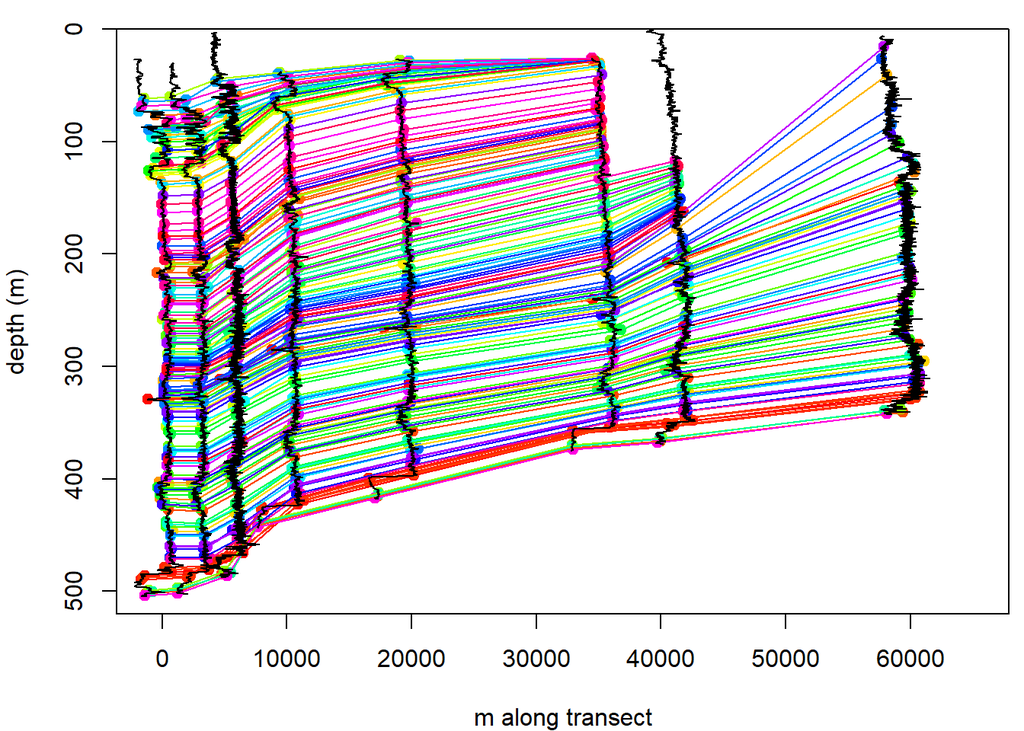

```r
#plot all the correlations lines in the transect ####
{
layout.matrix <- matrix(1,
                        nrow = 1,
                        ncol = 1,
                        byrow = TRUE)
layout(layout.matrix, heights = c(1), # Heights of the two rows
       widths = c(1))

par(mar = c(4, 4, 1, 0.5))


plot(
  x = c(-1000, max(readjusted_matrix_ord_2$distance_sum) * 1.1),
  y = c(525, 0),
  col = "white",
  xlab = "m along transect",
  ylab = "depth (m)",
  yaxs = "i",
  ylim = c(520, 0)
)            # Draw empty plot



comp_fact <- 4000

for (i in 1:length(prestreched_data_2)) {
  pts <- corr_points_2[[i]]
  points(
    y = pts[, 1],
    x = pts[, 2] * comp_fact + readjusted_matrix_ord_2$distance_sum[i],
    col = colors,
    pch = 19
  )

}

depth_mat_2 <- matrix(data = NA,
                      nrow = n_tiepoints,
                      ncol = length(data_tuned_cor))
val_mat_2 <- matrix(data = NA,
                    nrow = n_tiepoints,
                    ncol = length(data_tuned_cor))

for (i in 1:length(prestreched_data_2)) {
  pts <- corr_points_2[[i]]
  depth_mat_2[, i] <- pts[, 1]
  val_mat_2[, i] <- pts[, 2] * comp_fact + readjusted_matrix_ord_2$distance_sum[i]
}


for (i in 1:nrow(val_mat_2)) {
  #i <-35
  vals <- as.data.frame(cbind(val_mat_2[i, ], depth_mat_2[i, ]))
  lines(vals, col = colors[i])

}

for (i in 1:length(prestreched_data_2)) {
  lines(
    cbind(
      prestreched_data_2[[i]][2] * comp_fact + readjusted_matrix_ord_2$distance_sum[i],
      prestreched_data_2[[i]][1]
    )
  )
}
}
```

Plot the geological maps with the wells in the transect

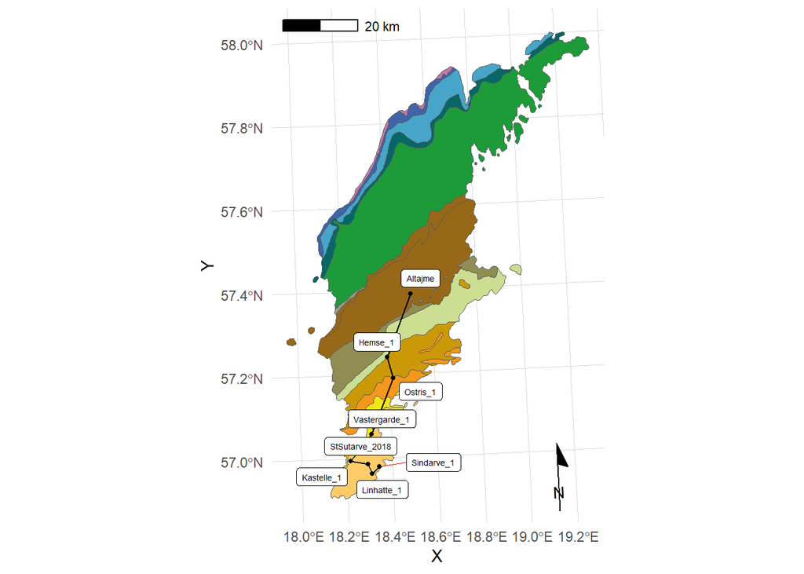

Figure 4C. Regional map with the location of the A’-A’’ transect in Figure 4B

```r
#plot the formations as polygons #####
library(ggplot2)
library(sf)
library(ggrepel)
library(ggspatial)
library(dplyr)

#------------------------------------------
# Define wells in the intended plotting order
#------------------------------------------
include_wells <- names(prestreched_data_2)

# Subset and reorder wells
well_tops_rotated_4 <- well_tops_rotated_3[
  well_tops_rotated_3$Well %in% include_wells, ]

# Force wells to follow intended order
well_tops_rotated_4$Well <- factor(well_tops_rotated_4$Well, levels = include_wells)
well_tops_rotated_4 <- well_tops_rotated_4[order(well_tops_rotated_4$Well), ]

#------------------------------------------
# Create a single LINESTRING connecting wells in order
#------------------------------------------
coords <- as.matrix(well_tops_rotated_4[, c("X", "Y")])
linesf <- st_sf(
  geometry = st_sfc(st_linestring(coords)),
  crs = st_crs(shapename)
)

#------------------------------------------
# Plot map with formations and geoline
#------------------------------------------
ggplot() +
  geom_sf(data = shapename) +

  # formations (example colors preserved)
  geom_sf(data = Visby,      fill = rgb(195, 121, 170, maxColorValue = 255)) +
  geom_sf(data = Hogklint,   fill = rgb(63, 100, 168,  maxColorValue = 255)) +
  geom_sf(data = Tofta,      fill = rgb(71, 165, 201,  maxColorValue = 255)) +
  geom_sf(data = Hangvar,    fill = "#076766ff") +
  geom_sf(data = Slite,      fill = "#1d9b38ff") +
  geom_sf(data = Frojel,     fill = "#999999ff") +
  geom_sf(data = Halla,      fill = "#976818ff") +
  geom_sf(data = L_Hemse,    fill = "#976818ff") +
  geom_sf(data = Etelheim,   fill = "#8f8d54ff") +
  geom_sf(data = Klinteberg, fill = "#ccde92ff") +
  geom_sf(data = Nar,        fill = "#cb9807ff") +
  geom_sf(data = Eke,        fill = "#f4981dff") +
  geom_sf(data = Brugsvik,   fill = "#f1e513ff") +
  geom_sf(data = Hamra,      fill = "#fdcc68ff") +

  #------------------------------------------
  # Add geoline and well labels
  #------------------------------------------
  geom_sf(data = linesf, linewidth = 0.5, color = "black") +
  geom_point(
    data = well_tops_rotated_4,
    aes(x = X, y = Y),
    size = 1,
    color = "black"
  ) +
  geom_label_repel(
    data = well_tops_rotated_4,
    aes(x = X, y = Y, label = Well),
    box.padding   = 0.2,
    point.padding = 0.2,
    size = 1.8,
    segment.color = 'red',
    segment.size  = 0.1,
    segment.alpha = 1,
    max.overlaps  = 50
  ) +

  #------------------------------------------
  # Scale bar, north arrow, coordinate system
  #------------------------------------------
  annotation_scale(location = "tl") +
  annotation_north_arrow(
    location = "br",
    which_north = "true",
    style = north_arrow_minimal()
  ) +
  coord_sf(default_crs = sf::st_crs(2400), clip = "off") +

  #------------------------------------------
  # Styling
  #------------------------------------------
  theme_minimal() +
  theme(
    panel.grid.major = element_line(color = "gray85", size = 0.2),
    panel.background = element_rect(fill = "white", color = NA)
  )
```

# DISCUSSION

## On the use of the DBA-based workflow for well-log correlations

This study introduces a comprehensive and reproducible workflow for DTW/DBA-based well-log correlation, implemented in the R programming language (see S.I.3). It advances existing DTW based approaches by combing two key innovations: (1), the incorporation of relative stratigraphic depth (re)scaling before DTW alignment, and (2) the iterative construction of a (regional) reference curve using Dynamic Time Warping with Barycenter Averaging (DBA). The (re)scaling step, which integrates geological expertise directly into the model, ensures that stratigraphic features known to correlate are aligned, even when they differ between well logs. Pre-stretching enhances the consistency of feature matching, improving both correlation accuracy and geological coherence. Correlation quality was assessed based on the continuity of characteristic log motifs and the preservation of stratigraphic relationships documented in the literature.

A total of six tie points were selected to achieve an optimal balance between geological guidance and algorithmic flexibility: fewer points led to correlations inconsistent with the established regional framework, whereas additional tie points risked over-constraining the DTW alignment and introducing interpretative bias. This limited set provided sufficient structure to maintain geological coherence without imposing excessive manual control, guiding the DBA algorithm in constructing a representative reference curve for the regional stratigraphy.

The manually defined tie points used to stretch the data in between the tie points acted as soft constraints rather than fixed anchors, providing broad stratigraphic guidance since the implemented workflow allowed DTW runs within the DBA modelling to redraw correlation paths based on signal similarity, thereby maintaining a balance between geological interpretation and objective, data-driven alignment. This approach is particularly effective in intervals where the confidence in the tie-points is uncertain rather than absolute.

It should be emphasised that the successful generation of a regional reference curve using the DBA algorithm was possible by the relatively high degree of similarity among the well logs, reflecting the basin’s “layer cake” stratigraphy. Nonetheless, careful pre-processing by means of the introduction of the tie-points was still essential, given the range of depositional environments represented in the dataset, from lagoonal and reefal facies to deeper basinal settings(Samtleben et al., 2000; Jorgensen et al., 2018; Biebesheimer et al., 2021; Hartke et al., 2021; Erlström et al., 2022).Although effective in this study, the use of a regional reference curve has its limitations, as such other DTW-based methods may be more appropriate in basins with significant lateral variability, such as those with meander belts, large prograding clinoforms, or turbidite deposits (Sylvester, 2023; Nieminski et al., 2024).

In summary, the combined pre-stretching and DBA-based reference curve workflow provides a rapid, robust approach for generating geologically consistent correlation lines across a basin. This study underscores the value of integrating independent stratigraphic information into DTW-based correlations, effectively merging traditional stratigraphic expertise with modern, data-driven techniques. Nevertheless, the resulting correlations should always be evaluated against established geological knowledge and adjusted where necessary to ensure an accurate and coherent interpretation of the basin’s stratigraphy.

## Subsurface stratigraphy and correlations in Gotland

The DBA-derived correlation lines enabled the subdivision of Gotland’s subsurface succession into fifteen units (see Figure 5), further refining the ten subdivisions previously proposed by Erlström et al. (2022) for Gotland’s subsurface. The fifteen intervals are correlated to previously established surface and shallow subsurface units on Gotland (Calner et al., 2004a, 2006; Eriksson and Calner, 2008; Biebesheimer et al., 2021; Hartke et al., 2021; Erlström et al., 2022; Stolfus et al., 2023). Unit names reference surface equivalent formations for convenience but do not imply formal naming or redefinition of the subsurface stratigraphy. Some uncertainty remains, especially for deeper units such as the Fröjel Formation and older units, which lack explicit surface correlations in the studied boreholes. Consequently, the stratigraphic naming convention used in this study should be viewed as tentative.

Plot the subsurface stratigraphy and along the transect

```r
#plot the formations as polygons #####

{
layout.matrix <- matrix(1,
                        nrow = 1,
                        ncol = 1,
                        byrow = TRUE)
layout(layout.matrix, heights = c(1), # Heights of the two rows
       widths = c(1))

par(mar = c(4, 4, 1, 0.5))


plot(
  x = c(-10000, max(readjusted_matrix_ord_2$distance_sum) * 1.1),
  y = c(525, 0),
  col = "white",
  xlab = "m along transect",
  ylab = "depth (m)",
  ylim = c(520, 0)
)            # Draw empty plot


comp_fact <- 4000

for (i in 1:length(prestreched_data_2)) {
  lines(
    cbind(
      prestreched_data_2[[i]][2] * comp_fact + readjusted_matrix_ord_2$distance_sum[i],
      prestreched_data_2[[i]][1]
    )
  )


}

depth_mat_sel <- matrix(data = NA, nrow = 8, ncol = 21)
val_mat_sel <- matrix(data = NA, nrow = 8, ncol = 21)

#readjusted_matrix_ord_2
names(readjusted_matrix_ord_2)

for (i in 1:8) {
  dt <-  as.data.frame(prestreched_data_2[[i]])
  dt <- na.omit(dt)
  x_vals <- as.data.frame(dt[, 2])
  y_vals <- as.data.frame(dt[, 1])
  for (j in 4:24) {
    if (!is.na(readjusted_matrix_ord_2[i, j])) {
      row_nr <- DescTools::Closest(readjusted_matrix_ord_2[i, j], y_vals, which = TRUE)
      val_mat_sel[i, j - 3] <- x_vals[row_nr[1], ]
      depth_mat_sel[i, j - 3] <- y_vals[row_nr[1], ]
      y_vals[row_nr[1], ]

    }
  }
}


depth_mat_sel <- depth_mat_sel[, c(7:ncol(depth_mat_sel))]
val_mat_sel <- val_mat_sel[, c(7:ncol(val_mat_sel))]
val_mat_sel <- val_mat_sel * comp_fact + readjusted_matrix_ord_2$distance_sum



Altajme_streched <- na.omit(
  cbind(
    well_logs_list_3[[38]][2] * comp_fact + readjusted_matrix_ord_2$distance_sum[8],
    well_logs_list_3[[38]][1]
  )
)


val_mat_sel <- val_mat_sel[, order(depth_mat_sel[1, ], decreasing = TRUE)]
depth_mat_sel <- depth_mat_sel[, order(depth_mat_sel[1, ], decreasing =
                                         TRUE)]

depth_mat_sel[3, 15] <-47
depth_mat_sel[8, 9] <- 130
depth_mat_sel[5, 14] <- 0
depth_mat_sel[8, 10] <- 0

Altajme_streched_sel_L_SIL <- Altajme_streched[Altajme_streched[, 2] < depth_mat_sel[8, 1], ]
Altajme_streched_sel_L_SIL <- Altajme_streched_sel_L_SIL[Altajme_streched_sel_L_SIL[, 2] >
                                                           depth_mat_sel[8, 2], ]


Altajme_streched_sel_l_visby <- Altajme_streched[Altajme_streched[, 2] <
                                                   depth_mat_sel[8, 2], ]
Altajme_streched_sel_l_visby <- Altajme_streched_sel_l_visby[Altajme_streched_sel_l_visby[, 2] >
                                                               depth_mat_sel[8, 3], ]


Altajme_streched_sel_u_visby <- Altajme_streched[Altajme_streched[, 2] <
                                                   depth_mat_sel[8, 3], ]
Altajme_streched_sel_u_visby <- Altajme_streched_sel_u_visby[Altajme_streched_sel_u_visby[, 2] >
                                                               depth_mat_sel[8, 4], ]

Altajme_streched_sel_Hogklint <- Altajme_streched[Altajme_streched[, 2] <
                                                    depth_mat_sel[8, 4], ]
Altajme_streched_sel_Hogklint <- Altajme_streched_sel_Hogklint[Altajme_streched_sel_Hogklint[, 2] >
                                                                 depth_mat_sel[8, 5], ]




Altajme_streched_sel_Tofta <- Altajme_streched[Altajme_streched[, 2] < depth_mat_sel[8, 5], ]
Altajme_streched_sel_Tofta <- Altajme_streched_sel_Tofta[Altajme_streched_sel_Tofta[, 2] >
                                                           depth_mat_sel[8, 6], ]

Altajme_streched_sel_Hangvar <- Altajme_streched[Altajme_streched[, 2] <
                                                   depth_mat_sel[8, 6], ]
Altajme_streched_sel_Hangvar <- Altajme_streched_sel_Hangvar[Altajme_streched_sel_Hangvar[, 2] >
                                                               depth_mat_sel[8, 7], ]

Altajme_streched_sel_Slite <- Altajme_streched[Altajme_streched[, 2] < depth_mat_sel[8, 7], ]
Altajme_streched_sel_Slite <- Altajme_streched_sel_Slite[Altajme_streched_sel_Slite[, 2] >
                                                           depth_mat_sel[8, 8], ]

Altajme_streched_sel_Mulde_1 <- Altajme_streched[Altajme_streched[, 2] <
                                                   depth_mat_sel[8, 8], ]
Altajme_streched_sel_Mulde_1 <- Altajme_streched_sel_Mulde_1[Altajme_streched_sel_Mulde_1[, 2] >
                                                               depth_mat_sel[8, 9], ]

Altajme_streched_sel_Mulde_2 <- Altajme_streched[Altajme_streched[, 2] <
                                                   depth_mat_sel[8, 9], ]
Altajme_streched_sel_Mulde_2 <- Altajme_streched_sel_Mulde_2[Altajme_streched_sel_Mulde_2[, 2] >
                                                               depth_mat_sel[8, 10], ]

colnames(Altajme_streched_sel_L_SIL) <- c("A", "B")
colnames(Altajme_streched_sel_l_visby) <- c("A", "B")
colnames(Altajme_streched_sel_u_visby) <- c("A", "B")
colnames(Altajme_streched_sel_Hogklint) <- c("A", "B")
colnames(Altajme_streched_sel_Tofta) <- c("A", "B")
colnames(Altajme_streched_sel_Hangvar) <- c("A", "B")
colnames(Altajme_streched_sel_Slite) <- c("A", "B")
colnames(Altajme_streched_sel_Mulde_1) <- c("A", "B")
colnames(Altajme_streched_sel_Mulde_2) <- c("A", "B")

bottom_Sil <- cbind(c(-5000, val_mat_sel[, 1]), c(depth_mat_sel[1, 1], depth_mat_sel[, 1]))
colnames(bottom_Sil) <- c("A", "B")
bottom_L_visby <- cbind(c(-5000, val_mat_sel[, 2]), c(depth_mat_sel[1, 2], depth_mat_sel[, 2]))
colnames(bottom_L_visby) <- c("A", "B")
bottom_u_visby <- cbind(c(-5000, val_mat_sel[, 3]), c(depth_mat_sel[1, 3], depth_mat_sel[, 3]))
colnames(bottom_u_visby) <- c("A", "B")
top_u_visby <- cbind(c(-5000, val_mat_sel[, 4]), c(depth_mat_sel[1, 4], depth_mat_sel[, 4]))
colnames(top_u_visby) <- c("A", "B")
top_Hogklint <- cbind(c(-5000, val_mat_sel[, 5]), c(depth_mat_sel[1, 5], depth_mat_sel[, 5]))
colnames(top_Hogklint) <- c("A", "B")
top_Tofta <- cbind(c(-5000, val_mat_sel[, 6]), c(depth_mat_sel[1, 6], depth_mat_sel[, 6]))
colnames(top_Tofta) <- c("A", "B")
top_Hangvar <- cbind(c(-5000, val_mat_sel[, 7]), c(depth_mat_sel[1, 7], depth_mat_sel[, 7]))
colnames(top_Hangvar) <- c("A", "B")
top_Slite <- cbind(c(-5000, val_mat_sel[, 8]), c(depth_mat_sel[1, 8], depth_mat_sel[, 8]))
colnames(top_Slite) <- c("A", "B")
top_Mulde_1 <- cbind(c(-5000, val_mat_sel[, 9]), c(depth_mat_sel[1, 9], depth_mat_sel[, 9]))
colnames(top_Mulde_1) <- c("A", "B")
top_Mulde_2 <- cbind(c(-5000, val_mat_sel[, 10]), c(depth_mat_sel[1, 10], depth_mat_sel[, 10]))
colnames(top_Mulde_2) <- c("A", "B")
```

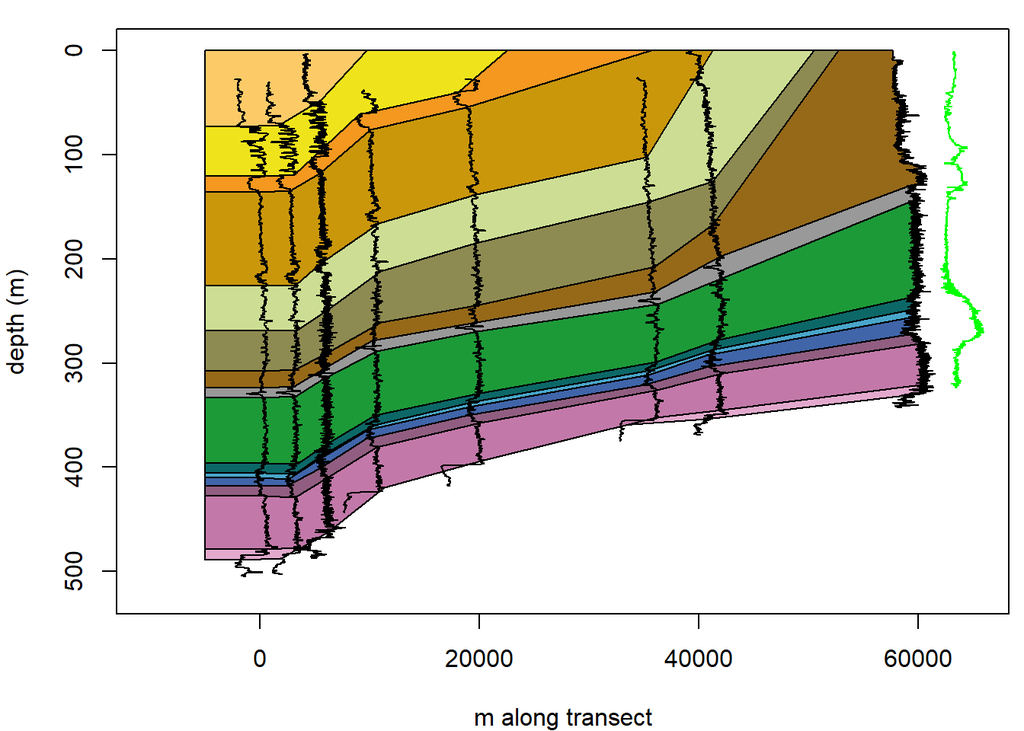

```r
top_Hemse <- cbind(c(-5000, val_mat_sel[, 11]), c(depth_mat_sel[1, 11], depth_mat_sel[, 11]))
colnames(top_Hemse) <- c("A", "B")
base_Etelheim_2 <- cbind(c(-5000, val_mat_sel[, 12]), c(depth_mat_sel[1, 12], depth_mat_sel[, 12]))
colnames(base_Etelheim_2) <- c("A", "B")
base_Eke <- cbind(c(-5000, val_mat_sel[, 13]), c(depth_mat_sel[1, 13], depth_mat_sel[, 13]))
colnames(base_Eke) <- c("A", "B")
base_Burgsvik <- cbind(c(-5000, val_mat_sel[, 14]), c(depth_mat_sel[1, 14], depth_mat_sel[, 14]))
colnames(base_Burgsvik) <- c("A", "B")
base_Hamra_Sundre <- cbind(c(-5000, val_mat_sel[, 15]), c(depth_mat_sel[1, 15], depth_mat_sel[, 15]))
colnames(base_Eke) <- c("A", "B")

L_Sil_col <- "#E2A9CD"
L_Visby_col <- "#C279A9"
U_Visby_col <- "#915E81"
Hogklint_col <- "#4065A9"
Tofta_col <- "#49A6CA"
Hangvar_col  <-  "#0C6867"
Slite_col   <- "#1D9A38"
Frojel_col  <- "#999999ff"
Halla_Klinteberg_col  <- "#966919"
L_Hemse_col  <- "#8E8B52"
Etelheim_col  <- "#CDDE94"
Nar_col  <- "#CA970B"
Eke_col  <- "#F49820"
Brugsvik_col <- "#EFE41B"
Hamra_Sundre_col <- "#FCCB68"

L_Sil <- rbind(bottom_Sil,
               Altajme_streched_sel_L_SIL[rev(order(Altajme_streched_sel_L_SIL[, 2])), ],
               bottom_L_visby[rev(order(bottom_L_visby[, 1])), ])

polygon(x = L_Sil[, 1],
        y = L_Sil[, 2],
        col = L_Sil_col)

L_Visby <- rbind(bottom_L_visby,
                 Altajme_streched_sel_l_visby[rev(order(Altajme_streched_sel_l_visby[, 2])), ],
                 bottom_u_visby[rev(order(bottom_u_visby[, 1])), ])
polygon(x = L_Visby[, 1],
        y = L_Visby[, 2],
        col = L_Visby_col)

U_Visby <- rbind(bottom_u_visby, Altajme_streched_sel_u_visby[rev(order(Altajme_streched_sel_u_visby[, 2])), ], top_u_visby[rev(order(top_u_visby[, 1])), ])

polygon(x = U_Visby[, 1],
        y = U_Visby[, 2],
        col = U_Visby_col)

Hogklint <- rbind(top_u_visby, Altajme_streched_sel_Hogklint[rev(order(Altajme_streched_sel_Hogklint[, 2])), ], top_Hogklint[rev(order(top_Hogklint[, 1])), ])
polygon(x = Hogklint[, 1],
        y = Hogklint[, 2],
        col = Hogklint_col)

Tofta <- rbind(top_Hogklint, Altajme_streched_sel_Tofta[rev(order(Altajme_streched_sel_Tofta[, 2])), ], top_Tofta[rev(order(top_Tofta[, 1])), ])
polygon(x = Tofta[, 1],
        y = Tofta[, 2],
        col = Tofta_col)

Hangvar <- rbind(top_Tofta, Altajme_streched_sel_Hangvar[rev(order(Altajme_streched_sel_Hangvar[, 2])), ], top_Hangvar[rev(order(top_Hangvar[, 1])), ])
polygon(x = Hangvar[, 1],
        y = Hangvar[, 2],
        col = Hangvar_col)


top_Slite <- top_Slite[1:7, ]

Slite <- rbind(top_Hangvar,
               Altajme_streched_sel_Slite[rev(order(Altajme_streched_sel_Slite[, 2])), ],
               top_Slite[rev(order(top_Slite[, 1])), ])

polygon(x = Slite[, 1],
        y = Slite[, 2],
        col = Slite_col)


Mulde_1 <- rbind(top_Slite,
                 Altajme_streched_sel_Mulde_1[rev(order(Altajme_streched_sel_Mulde_1[, 2])), ],
                 top_Mulde_1[rev(order(top_Mulde_1[, 1])), ])
polygon(x = Mulde_1[, 1],
        y = Mulde_1[, 2],
        col = Frojel_col)

top_Mulde_2_sel <- top_Mulde_2[rev(order(top_Mulde_2[, 1])), ]
top_Mulde_2_sel <- top_Mulde_2_sel[2:8, ]

Mulde_2 <- rbind(
  top_Mulde_1,
  Altajme_streched_sel_Mulde_2[rev(order(Altajme_streched_sel_Mulde_2[, 2])), ],
  c(Altajme_streched_sel_Mulde_2[1, 1], 0),
  c(Altajme_streched_sel_Mulde_2[1, 1] - 5000, 0),
  top_Mulde_2_sel,
  c(-5000,top_Mulde_2_sel[nrow(top_Mulde_2_sel),2])
)
polygon(x = Mulde_2[, 1],
        y = Mulde_2[, 2],
        col = Halla_Klinteberg_col)







L_Hemse <- rbind(
  top_Mulde_2[1:8, ],
  c(Altajme_streched_sel_Mulde_2[1, 1] - 5000, 0),
  c(Altajme_streched_sel_Mulde_2[1, 1] - 7250, 0),
  na.omit(top_Hemse[rev(order(top_Hemse[, 1])), ])
)
polygon(x = L_Hemse[, 1],
        y = L_Hemse[, 2],
        col = L_Hemse_col)



top_Hemse_sel <- na.omit(top_Hemse[rev(order(top_Hemse[, 1])), ])

Etelheim <- rbind(
  na.omit(top_Hemse),
  c(Altajme_streched_sel_Mulde_2[1, 1] - 7250, 0),
  c(top_Hemse_sel[1, 1], 0),
  na.omit(base_Etelheim_2[rev(order(base_Etelheim_2[, 1])), ])
)
polygon(x = Etelheim[, 1],
        y = Etelheim[, 2],
        col = Etelheim_col)

base_Eke_sel <- na.omit(base_Eke[rev(order(base_Eke[, 1])), ])

Nar <- rbind(
  na.omit(base_Etelheim_2),
  c(top_Hemse_sel[1, 1], 0),
  c(base_Eke_sel[1, 1] + 500, 0),
  na.omit(base_Eke[rev(order(base_Eke[1:6, 1])), ])
)


polygon(x = Nar[, 1],
        y = Nar[, 2],
        col = Nar_col)

base_Burgsvik[5, 2] <- base_Burgsvik[5, 2]-6
base_Burgsvik[6,2] <- 40

Eke <- rbind(na.omit(base_Eke[c(1:6), ]),
             c(base_Eke_sel[1, 1] + 500, 0),
             c((22 * 1000) + 500, 0),
             na.omit(base_Burgsvik[rev(order(base_Burgsvik[1:6, 1])), ]))



polygon(x = Eke[, 1],
        y = Eke[, 2],
        col = Eke_col)

base_base_Burgsvik_sel <- na.omit(base_Burgsvik[rev(order(base_Burgsvik[, 1])), ])

Burgsvik <- rbind(
  na.omit(base_Burgsvik[1:6, ]),
  c((22 * 1000) + 500, 0),
  c(base_Hamra_Sundre[5, 1], 0),
  na.omit(base_Hamra_Sundre[rev(order(base_Hamra_Sundre[1:4, 1])), ])
)

polygon(x = Burgsvik[, 1],
        y = Burgsvik[, 2],
        col = Brugsvik_col)


Hamra_Sundre <- rbind(na.omit(base_Hamra_Sundre[1:4, ]),
                      c(base_Hamra_Sundre[5, 1], 0),
                      c(-5000, 0))

polygon(x = Hamra_Sundre[, 1],
        y = Hamra_Sundre[, 2],
        col = Hamra_Sundre_col)



for (i in 1:length(prestreched_data_2)) {
  lines(
    cbind(
      prestreched_data_2[[i]][2] * comp_fact + readjusted_matrix_ord_2$distance_sum[i],
      prestreched_data_2[[i]][1]
    )
  )


}

# add  the d13C record to the plot
Altamje_d13C <- read.csv("https://raw.githubusercontent.com/stratigraphy/DTW-Gotland/main/Altamje_d13C.csv")
Altamje_d13C <- demean(Altamje_d13C, genplot = F, verbose = F)
Altamje_d13C[, 2]  <- Altamje_d13C[, 2] - min(Altamje_d13C[, 2])
Altamje_d13C[, 2]  <- Altamje_d13C[, 2] / max(Altamje_d13C[, 2])
Altamje_d13C <- iso(Altamje_d13C,
                    xmax = 324,
                    xmin = 0,
                    genplot = FALSE,verbose = F)
lines(
  x = (Altamje_d13C[, 2] * 4000) + 62000,
  y = Altamje_d13C[, 1],
  col = "green"
)
}
```

Plot the subsurface stratigraphy in the reference curve (generated by the DBA algorithm as part of the correlation process), St.Sutarve-2018, and Altajme wells.

```r
#plot the formations as polygons #####
#plot ages  litholog reference and st.Sutarve-2018 and Altajme ######
{
Llandovery_col <- geo_col(name = "Llandovery")
Wenlock_col <- geo_col(name = "Wenlock")
Telychian_col <- geo_col(name = "Telychian")
Sheinwoodian_col <- geo_col(name = "Sheinwoodian")
Homerian_col <- geo_col(name = "Homerian")
Rhuddanian_col <- geo_col(name = "Rhuddanian")
Aeronian_col <- geo_col(name = "Aeronian")
Ludfordian_col <- geo_col(name = "Ludfordian")
Ludlow_col <- geo_col(name = "Ludlow")
Gorstian_col <- geo_col(name = "Gorstian")
Ord_col <- geo_col(name = "Ordovician")


L_Sil_col <- "#E2A9CD"
L_Visby_col <- "#C279A9"
U_Visby_col <- "#915E81"
Hogklint_col <- "#4065A9"
Tofta_col <- "#49A6CA"
Hangvar_col  <-  "#0C6867"
Slite_col   <- "#1D9A38"
Frojel_col  <- "#999999ff"
Halla_Klinteberg_col  <- "#966919"
L_Hemse_col  <- "#8E8B52"
Etelheim_col  <- "#CDDE94"
Nar_col  <- "#CA970B"
Eke_col  <- "#F49820"
Brugsvik_col <- "#EFE41B"
Hamra_Sundre_col <- "#FCCB68"

shift_down <- 60
# plot(
#   y = (a[tie_points, 1] / 10) + shift_down,
#   x = a[tie_points, 2] - 1 ,
#   col = colors,
#   pch = 19,
#   cex = 0.75
# )
#
# a_sort <- a[tie_points[order(a[tie_points, 1]),],1]/10
# a_sort
#
# plot(
#   y = c(a[, 1] / 10)+shift_down,
#   x = a[, 2] ,type="l",
#   ylim=c(450,300)
# )
#
# depth_mat_sel
#
# readjusted_matrix_ord

ref_base_hogklint <-base_hogklint[1]
#base Silurian


ref_base_silurian <- readjusted_matrix_ord$base_silurian[1]

ref_base_l_Visby <-readjusted_matrix_ord$base_L_visby[1]

#base upper Visby
ref_base_u_Visby <- readjusted_matrix_ord$base_U_visby[1]

#base Tofta
ref_base_Tofta <- readjusted_matrix_ord$base_Tofta[1]

#base Hangvar
ref_base_Hangvar <- readjusted_matrix_ord$base_Hangvar[1]
#base Slite
ref_base_Slite <- readjusted_matrix_ord$base_Slite[1]
#base Halla # start Mulde
ref_base_Halla <- readjusted_matrix_ord$base_Klinteberg[1]
#base hemse near end Mulde
ref_base_Hemse <- readjusted_matrix_ord$base_Hemse[1]
#base Etelhem
ref_base_Etelhem <- readjusted_matrix_ord$base_Etelhem[1]
#base Nar
ref_base_Nar <-readjusted_matrix_ord$base_Nar[1]
#base EKE
ref_base_EKE <- readjusted_matrix_ord$base_EKE[1]
#base Burgsvik
ref_base_Burgsvik <- readjusted_matrix_ord$base_Burgsvik[1]
#base Hamra Sundre
ref_base_Ham_Sund <- readjusted_matrix_ord$base_Hamra_Sundre[1]
#base Frojel
ref_base_Frojel <- readjusted_matrix_ord$base_Frojel[1]
#base klinteberg
ref_base_Klinteberg <- readjusted_matrix_ord$base_Klinteberg[1]


{
layout.matrix <-
  matrix(c(1:4), nrow = 1, ncol = 4)

layout(layout.matrix,
       heights = c(1),
       widths = c(1,1,1,2))
par(mar = c(4, 4, 4, 0))

ylims <- c(max((a[, 1] / 10))+2.5+shift_down,0)


plot(
  x = c(0, 1),
  y = c(0, max(ylims)),
  col = "white",
  xlab = "",
  ylab = "Normalised depth (m)",
  xaxt = "n",
  xaxs = "i",
  yaxs = "i",
  ylim = ylims,main="Epoch"
) # Draw empty plot

polygon(
  x = c(0, 1, 1, 0),
  y = c(
    ref_base_silurian,
    ref_base_silurian,
    max(ylims),
    max(ylims)
  ),
  col = Ord_col
)



polygon(
  x = c(0, 1, 1, 0),
  y = c(
    ref_base_silurian,
    ref_base_silurian,
    ref_base_l_Visby,
    ref_base_l_Visby
  ),
  col = Aeronian_col
)

text(x=0.5,y=(ref_base_silurian+(ref_base_l_Visby))/2,
     label="L-Sil")

polygon(
  x = c(0, 1, 1, 0),
  y = c(
    ref_base_l_Visby,
    ref_base_l_Visby,
    ref_base_u_Visby,
    ref_base_u_Visby

  ),
  col = Llandovery_col
)

text(x=0.5,y=(ref_base_l_Visby+(ref_base_u_Visby))/2,
     label="Llanovery")


polygon(
  x = c(0, 1, 1, 0),
  y = c(
    ref_base_u_Visby,
    ref_base_u_Visby,
    ref_base_Hemse,
    ref_base_Hemse
  ),
  col = Wenlock_col
)

text(x=0.5,y=(ref_base_Hemse+(ref_base_u_Visby))/2,
     label="Wenlock")

polygon(
  x = c(0, 1, 1, 0),
  y = c(
    ref_base_Hemse,
    ref_base_Hemse,
    0,0
  ),
  col = Ludfordian_col
)

text(x=0.5,y=(ref_base_Hemse+(0))/2,
     label="Ludlow")


par(mar = c(4, 0, 4, 0))

plot(
  x = c(0, 1),
  y = c(0, max(ylims)),
  col = "white",
  xlab = "",
  ylab = "depth (m)",
  xaxt = "n",
  xaxs = "i",
  yaxs = "i",
  yaxt="n",
  ylim = ylims,main="Age"
) # Draw empty plot



polygon(
  x = c(0, 1, 1, 0),
  y = c(
    527.5,
    527.5,
    ref_base_silurian,
    ref_base_silurian
  ),
  col = Ord_col
)

polygon(
  x = c(0, 1, 1, 0),
  y = c(
    ref_base_silurian,
    ref_base_silurian,
    ref_base_l_Visby,
    ref_base_l_Visby
  ),
  col = Aeronian_col
)

text(x=0.5,y=(ref_base_silurian+(ref_base_l_Visby))/2,
     label="Aeronian")

polygon(
  x = c(0, 1, 1, 0),
  y = c(
    ref_base_l_Visby,
    ref_base_l_Visby,
    ref_base_u_Visby+1.5,
    ref_base_u_Visby+1.5

  ),
  col = Llandovery_col
)

text(x=0.5,y=(ref_base_u_Visby+(ref_base_l_Visby))/2,
     label="Llandovery")

polygon(
  x = c(0, 1, 1, 0),
  y = c(
    ref_base_u_Visby+1.5,
    ref_base_u_Visby+1.5,
    (ref_base_Slite+ref_base_Halla)/2,
    (ref_base_Slite+ref_base_Halla)/2
  ),
  col = Sheinwoodian_col
)

text(x=0.5,y=(ref_base_u_Visby+1.5+(ref_base_Slite+ref_base_Halla)/2)/2,
     label="Sheinwoodian")

polygon(
  x = c(0, 1, 1, 0),
  y = c(
    (ref_base_Slite+ref_base_Halla)/2,
    (ref_base_Slite+ref_base_Halla)/2,
    ref_base_Hemse,
    ref_base_Hemse
  ),
  col = Homerian_col
)


text(x=0.5,y=(ref_base_Hemse+((ref_base_Slite+ref_base_Halla)/2))/2,
     label="Homerian")

polygon(
  x = c(0, 1, 1, 0),
  y = c(

    ref_base_Hemse,
    ref_base_Hemse,
    ref_base_Etelhem,
    ref_base_Etelhem
  ),
  col = Gorstian_col
)
text(x=0.5,y=(ref_base_Hemse+ref_base_Etelhem)/2,
     label="Gorstian")


polygon(
  x = c(0, 1, 1, 0),
  y = c(
    ref_base_Etelhem,
    ref_base_Etelhem,
    0,
    0
  ),
  col = Ludfordian_col
)

text(x=0.5,y=(0+ref_base_Etelhem)/2,
     label="Ludfordian")


par(mar = c(4, 0, 4, 0))

plot(
  x = c(0, 1),
  y = c(0, max(ylims)),
  col = "white",
  xlab = "",
  ylab = "depth (m)",
  xaxt = "n",
  xaxs = "i",
  yaxs = "i",
  yaxt="n",
  ylim = ylims,main="Lith. strat"
) # Draw empty plot


polygon(
  x = c(0, 1, 1, 0),
  y = c(
    527.5,
    527.5,
    ref_base_silurian,
    ref_base_silurian
  )
)
```

```r
text(x=0.5,y=prestreched_data[[1]][1, 3]/3+(525+(ref_base_silurian))/2,label="Ord")


polygon(
  x = c(0, 1, 1, 0),
  y = c(
    ref_base_silurian,
    ref_base_silurian,
    ref_base_l_Visby,
    ref_base_l_Visby
  ))


text(x=0.5,y=(ref_base_silurian+(ref_base_l_Visby))/2,
     label="L-Sil")


polygon(
  x = c(0, 1, 1, 0),
  y = c(
    ref_base_l_Visby,
    ref_base_l_Visby,
    ref_base_u_Visby,
    ref_base_u_Visby

  )
)

text(x=0.5,y=(ref_base_u_Visby+(ref_base_l_Visby))/2,
     label="L-Visby")


polygon(
  x = c(0, 1, 1, 0),
  y = c(
    ref_base_u_Visby,
    ref_base_u_Visby,
    ref_base_hogklint,
    ref_base_hogklint
  ),
  col =
)

text(x=0.5,y=(ref_base_u_Visby+(ref_base_hogklint))/2,
     label="U-Visby")



polygon(
  x = c(0, 1, 1, 0),
  y = c(
    ref_base_hogklint,
    ref_base_hogklint,
    ref_base_Tofta,
    ref_base_Tofta
  ),
  col =
)

text(x=0.5,y=(ref_base_Tofta+(ref_base_hogklint))/2,
     label="Hogklint")


polygon(
  x = c(0, 1, 1, 0),
  y = c(
    ref_base_Tofta,
    ref_base_Tofta,
    ref_base_Hangvar,
    ref_base_Hangvar
  ),
  col =
)

text(x=0.5,y=(ref_base_Tofta+(ref_base_Hangvar))/2,
     label="Tofta")



polygon(
  x = c(0, 1, 1, 0),
  y = c(
    ref_base_Hangvar,
    ref_base_Hangvar,
    ref_base_Slite,
    ref_base_Slite
  ),
  col =
)

text(x=0.5,y=(ref_base_Slite+(ref_base_Hangvar))/2,
     label="Hangvar")


polygon(
  x = c(0, 1, 1, 0),
  y = c(
    ref_base_Slite,
    ref_base_Slite,
    ref_base_Halla,
    ref_base_Halla
  ),
  col =
)

text(x=0.5,y=(ref_base_Slite+(ref_base_Halla))/2,
     label="Slite")



polygon(
  x = c(0, 1, 1, 0),
  y = c(
    ref_base_Frojel,
    ref_base_Frojel,
    ref_base_Klinteberg,
    ref_base_Klinteberg
  ),
  col =
)

text(x=0.5,y=(ref_base_Frojel+(ref_base_Klinteberg))/2,
     label="Frojel")


polygon(
  x = c(0, 1, 1, 0),
  y = c(
    ref_base_Klinteberg,
    ref_base_Klinteberg,
    ref_base_Hemse,
    ref_base_Hemse
  ),
  col =
)

text(x=0.5,y=(ref_base_Klinteberg+(ref_base_Hemse))/2,
     label="Klinteberg Fm /Halla Fm")


polygon(
  x = c(0, 1, 1, 0),
  y = c(
    ref_base_Hemse,
    ref_base_Hemse,
    ref_base_Etelhem,
    ref_base_Etelhem
  ),
  col =
)

text(x=0.5,y=(ref_base_Hemse+(ref_base_Etelhem))/2,
     label="L-Hemse Marl Fm")


polygon(
  x = c(0, 1, 1, 0),
  y = c(
    ref_base_Etelhem,
    ref_base_Etelhem,
    ref_base_Nar,
    ref_base_Nar
  ),
  col =
)

text(x=0.5,y=(ref_base_Etelhem+(ref_base_Nar))/2,
     label="Etelhem Fm")


polygon(
  x = c(0, 1, 1, 0),
  y = c(
    ref_base_Nar,
    ref_base_Nar,
    ref_base_EKE,
    ref_base_EKE
  ),
  col =
)

text(x=0.5,y=(ref_base_Nar+(ref_base_EKE))/2,
     label="Nar Fm")

polygon(
  x = c(0, 1, 1, 0),
  y = c(
    ref_base_EKE,
    ref_base_EKE,
    ref_base_Burgsvik,
    ref_base_Burgsvik
  ),
  col =
)

text(x=0.5,y=(ref_base_Burgsvik+(ref_base_EKE))/2,
     label="Eke Fm")


polygon(
  x = c(0, 1, 1, 0),
  y = c(
    ref_base_Burgsvik,
    ref_base_Burgsvik,
    ref_base_Ham_Sund,
    ref_base_Ham_Sund
  ),
  col =
)

text(x=0.5,y=(ref_base_Burgsvik+(ref_base_Ham_Sund))/2,
     label="Burgsvik Fm")


polygon(
  x = c(0, 1, 1, 0),
  y = c(
    ref_base_Ham_Sund,
    ref_base_Ham_Sund,
    0,
    0
  ),
  col =
)

text(x=0.5,y=(50+(ref_base_Ham_Sund))/2,
     label="Hamra/Sundre Fm")

par(mar = c(4, 0, 4, 4))

plot(a[, 2], (a[, 1] / 10)+shift_down ,xlab="",yaxs = "i",xaxt="n",
     col = "black", lwd = 1,type="l",xlim=c(-1,3.75),ylim=ylims,yaxt="n",xaxs="i",
     ,main="well-log correlation")


polygon(
  x = c(-1,3.75,3.75,2.5,2,0.75,0.25, -1),
  y = c(
    527.5,
    527.5,
    L_Sil[9,2],
    L_Sil[9,2],
    L_Sil[4,2],
    L_Sil[4,2],
    ref_base_silurian,
    ref_base_silurian
  ),col=Ord_col
)

polygon(
  x = c(-1,0.25,0.75,2,2.5,3.75,3.75,2.5,
        2,0.75,0.25, -1),
  y = c(
    ref_base_silurian,
    ref_base_silurian,
    L_Sil[4,2],
    L_Sil[4,2],
    L_Sil[9,2],
    L_Sil[9,2],
    L_Visby[9,2],
    L_Visby[9,2],
    L_Visby[4,2],
    L_Visby[4,2],
    ref_base_l_Visby,
    ref_base_l_Visby

  ),col=L_Sil_col)


polygon(
  x = c(-1,0.25,0.75,2,2.5,3.75,3.75,2.5,
        2,0.75,0.25, -1),
  y = c(
    ref_base_l_Visby,
    ref_base_l_Visby,
    L_Visby[4,2],
    L_Visby[4,2],
    L_Visby[9,2],
    L_Visby[9,2],
    U_Visby[9,2],
    U_Visby[9,2],
    U_Visby[4,2],
    U_Visby[4,2],
    ref_base_u_Visby,
    ref_base_u_Visby

  ),col=L_Visby_col)


polygon(
  x = c(-1,0.25,0.75,2,2.5,3.75,3.75,2.5,
        2,0.75,0.25, -1),  y = c(
    ref_base_u_Visby,
    ref_base_u_Visby,
    U_Visby[4,2],
    U_Visby[4,2],
    U_Visby[9,2],
    U_Visby[9,2],
    Hogklint[9,2],
    Hogklint[9,2],
    Hogklint[4,2],
    Hogklint[4,2],
    ref_base_hogklint,
    ref_base_hogklint

  ),col=U_Visby_col)




polygon(
  x = c(-1,0.25,0.75,2,2.5,3.75,3.75,2.5,
        2,0.75,0.25, -1),  y = c(
    ref_base_hogklint,
    ref_base_hogklint,
    Hogklint[4,2],
    Hogklint[4,2],
    Hogklint[9,2],
    Hogklint[9,2],
    Tofta[9,2],
    Tofta[9,2],
    Tofta[4,2],
    Tofta[4,2],
    ref_base_Tofta,
    ref_base_Tofta

  ),col=Hogklint_col)

polygon(
  x = c(-1,0.25,0.75,2,2.5,3.75,3.75,2.5,
        2,0.75,0.25, -1),  y = c(
    ref_base_Tofta,
    ref_base_Tofta,
    Tofta[4,2],
    Tofta[4,2],
    Tofta[9,2],
    Tofta[9,2],
    Hangvar[9,2],
    Hangvar[9,2],
    Hangvar[4,2],
    Hangvar[4,2],
    ref_base_Hangvar,
    ref_base_Hangvar

  ),col=Tofta_col)


polygon(
  x = c(-1,0.25,0.75,2,2.5,3.75,3.75,2.5,
        2,0.75,0.25, -1),  y = c(
    ref_base_Hangvar,
    ref_base_Hangvar,
    Hangvar[4,2],
    Hangvar[4,2],
    Hangvar[9,2],
    Hangvar[9,2],
    Slite[9,2],
    Slite[9,2],
    Slite[4,2],
    Slite[4,2],
    ref_base_Slite,
    ref_base_Slite

  ),col=Hangvar_col)


polygon(
  x = c(-1,0.25,0.75,2,2.5,3.75,3.75,2.5,
        2,0.75,0.25, -1),  y = c(
    ref_base_Slite,
    ref_base_Slite,
    Slite[4,2],
    Slite[4,2],
    Slite[9,2],
    Slite[9,2],
    Mulde_1[9,2],
    Mulde_1[9,2],
    Mulde_1[4,2],
    Mulde_1[4,2],
    ref_base_Frojel,
    ref_base_Frojel
```

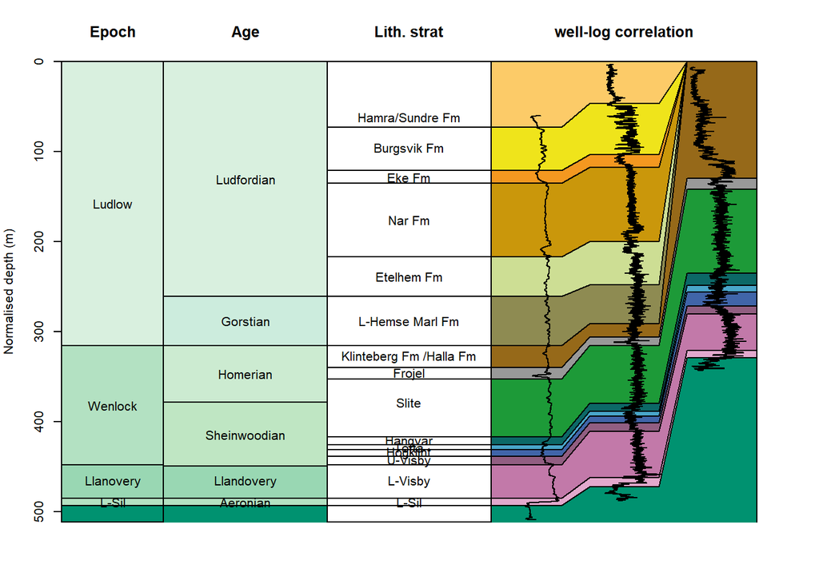

```r
  ),col=Slite_col)

polygon(
  x = c(-1,0.25,0.75,2,2.5,3.75,3.75,2.5,
        2,0.75,0.25, -1),  y = c(
    ref_base_Frojel,
    ref_base_Frojel,
    Mulde_1[4,2],
    Mulde_1[4,2],
    Mulde_1[9,2],
    Mulde_1[9,2],
    Mulde_2[9,2],
    Mulde_2[9,2],
    Mulde_2[4,2],
    Mulde_2[4,2],
    ref_base_Klinteberg,
    ref_base_Klinteberg

  ),col=Frojel_col)

polygon(
  x = c(-1,0.25,0.75,2,2.5,3.75,3.75,2.5,
        2,0.75,0.25, -1),  y = c(
    ref_base_Klinteberg,
    ref_base_Klinteberg,
    Mulde_2[4,2],
    Mulde_2[4,2],
    Mulde_2[9,2],
    Mulde_2[9,2],0,
    0,
    L_Hemse[4,2],
    L_Hemse[4,2],
    ref_base_Hemse,
    ref_base_Hemse

  ),col=Halla_Klinteberg_col)


polygon(
  x = c(-1,0.25,0.75,2,2.5,2,0.75,0.25, -1),
  y = c(
    ref_base_Hemse,
    ref_base_Hemse,
    L_Hemse[4,2],
    L_Hemse[4,2],
    0,
    Etelheim[4,2],
    Etelheim[4,2],
    ref_base_Etelhem,
    ref_base_Etelhem

  ),col=L_Hemse_col)

polygon(
  x = c(-1,0.25,0.75,2,2.5,2,0.75,0.25, -1),
  y = c(
    ref_base_Etelhem,
    ref_base_Etelhem,
    Etelheim[4,2],
    Etelheim[4,2],
    0,
    Nar[4,2]-4,
    Nar[4,2]-4,
    ref_base_Nar,
    ref_base_Nar

  ),col=Etelheim_col)


polygon(
  x = c(-1,0.25,0.75,2,2.5,2,0.75,0.25, -1),
  y = c(
    ref_base_Nar,
    ref_base_Nar,
    Nar[4,2]-4,
    Nar[4,2]-4,
    0,
    Eke[4,2],
    Eke[4,2],
    ref_base_EKE,
    ref_base_EKE

  ),col=Nar_col)


polygon(
  x = c(-1,0.25,0.75,2,2.5,2,0.75,0.25, -1),
  y = c(
    ref_base_EKE,
    ref_base_EKE,
    Eke[4,2],
    Eke[4,2],
    0,
    Burgsvik[4,2],
    Burgsvik[4,2],
    ref_base_Burgsvik,
    ref_base_Burgsvik

  ),col=Eke_col)

polygon(
  x = c(-1,0.25,0.75,2,2.5,2,0.75,0.25, -1),
  y = c(
    ref_base_Burgsvik,
    ref_base_Burgsvik,
    Burgsvik[4,2],
    Burgsvik[4,2],
    0,
    Hamra_Sundre[4,2],
    Hamra_Sundre[4,2],
    ref_base_Ham_Sund,
    ref_base_Ham_Sund

  ),col=Brugsvik_col)

polygon(
  x = c(-1,0.25,0.75,2,2.5,2,0.75,0.25, -1),
  y = c(
    ref_base_Ham_Sund,
    ref_base_Ham_Sund,
    Hamra_Sundre[4,2],
    Hamra_Sundre[4,2],
    0,
    0,
    0,
    0,
    0
  ),col=Hamra_Sundre_col)

lines(a[, 2], (a[, 1] / 10)+shift_down,lwd=1)
lines((prestreched_data_2$StSutarve_2018[,2])+1.5,prestreched_data_2$StSutarve_2018[,1],lwd=1)
lines((prestreched_data_2$Altajme[,2])+3,prestreched_data_2$Altajme[,1],lwd=1)

}
}
```

The stratigraphically lowest and oldest Silurian unit identified in this study is not exposed at the surface. This unit has to date been identified only in the Grötlingbo-1 well/core, based on an integrated biostratigraphic study indicating the presence of a Rhuddanian to Aeronian-aged unit, separated by a gap spanning the late Aeronian to early Telychian (Männik et al., 2015).The lower Silurian unit is typified by higher gamma-ray values than the overlying Lower Visby Formation. A sharp rise in gamma-ray intensity marks the base of the lower Silurian unit. Variations in thickness and gamma-ray response within this unit create uncertainty about consistently assigning it to a specific stage or biostratigraphic interval across the study area. Further research is needed to clarify its stratigraphic affinity.

The base of the Lower Visby Formation coincides with a transition from the high gamma-ray values of the lower Silurian unit to the stable and moderately high gamma-ray values of the Lower Visby Formation. The top of the Lower Visby is marked by a peak in the gamma-ray log. This peak is preceded by a smaller peak in the gamma-ray log, which marks the onset of a minor rise in the δ¹³Ccarb curve, associated with the Ireviken Event (see Figure 5A). The smaller gamma-ray peak likely represents the onset of a period of enhanced primary productivity before the Ireviken Extinction Event (Vandenbroucke et al., 2013; Hartke et al., 2021; Stolfus et al., 2023).The smaller gamma-ray peak below the Lower to Upper Visby Formation boundary can be easily traced across the different well logs, confirming its utility for stratigraphic correlation. The base of the Lower Visby Formation coincides with a transition from the high gamma-ray values of the lower Silurian unit to the stable and moderately high gamma-ray values of the Lower Visby Formation.

The Upper Visby Formation corresponds to an interval of rising δ¹³Ccarb values and a steady decrease in gamma-ray log values (Figure 5). In the well logs spanning the transect between the Sindarve-1 and Vastergade-1 wells, two small but noticeable peaks are observed, superimposed on the declining trend in the gamma-ray log of the Upper Visby Formation (see Figure 5). These two peaks are absent in the shallower part of the basin that spans the Ostris-1, Hemse-1, and Altajme wells. The absence of these peaks suggests that part of the Upper Visby Formation is missing in the shallower parts of the basin, which is consistent with the unconformable nature observed for some of the boundaries between the Upper Visby Formation and the Högklint Formation (Manten, 1971; Jeppsson et al., 2006; Cramer, 2009). The variable gamma-ray response of this boundary necessitated manual tracking of the formation boundary, highlighting a limitation in the process that generated the DBA-based correlation lines.

The Högklint Formation is characterised by low gamma-ray values that increase gradually. In the Altajme Core, this unit is typified by numerous small, positive δ¹³Ccarb peaks (~1‰) that are superimposed on the larger peak. Sadly, the gamma-ray log lacks the resolution to resolve these finer-scale geochemical features. A distinct positive inflexion in the gamma-ray log marks the boundary with the overlying Tofta Formation. Stable, high δ¹³Ccarb values and low gamma-ray values typify the Tofta Formation. A positive gamma-ray inflexion marks its upper boundary with the Hangvar Formation.

The Hangvar Formation is characterised by numerous small negative δ¹³Ccarb peaks (~1‰) that are superimposed on a larger declining trend (Hartke et al., 2021). Unfortunately, the gamma-ray log lacks the resolution to describe the relationship between the log and these small δ¹³Ccarb peaks. In the Hangvar Formation, gamma-ray values first drop, then rise gradually. The transition to the Slite Group is marked by a shift toward more stable baseline gamma-ray values.

Consistently high gamma-ray values characterise the Slite Group and lack internal features suitable for further subdivision. A sharp negative inflexion in the gamma-ray log characterises its boundary with the overlying Fröjel Formation.

The Fröjel Formation exhibits a distinct gamma-ray trough followed by a sharp positive inflexion at its upper boundary, which coincides with a rise in δ13Ccarb values and the extinction interval of the Mulde Event (Hartke et al., 2021; Stolfus et al., 2023).

The Halla/Klinteberg formations are characterised by intermediate gamma-ray values forming a broad trough between the lower values of the Fröjel Formation and the higher values of the Slite Group. The Halla/Klinteberg formations lack clear internal markers, which prevents subdivision at the formation level. The Halla/Klinteberg formations correspond to the double δ13Ccarb peak of the Mulde Event (Calner et al., 2004a; Radzevicius, 2014; Biebesheimer et al., 2021). The notably greater thickness of the Halla/Klinteberg formations in the Altajme and Vike-1 wells, compared to more southerly locations, reflects enhanced reef development during the Mulde Event (Samtleben et al., 2000; McLaughlin et al., 2019; Biebesheimer et al., 2021). TThe significant difference between the Altajme well/core and other records hinders the correlation of the δ13Ccarb peaks into the distal part of the basin. High-resolution δ13Ccarb profiles are therefore needed to better understand the relationship between gamma-ray log patterns and the carbon-isotope signal. Moreover, reefal influence in the Altajme core has altered the gamma-ray expression of the Halla/Klinteberg and possibly the Fröjel formations, making it unrepresentative of the more distal southern wells. Within the broader correlation framework, the gamma-ray motif of the St. Sutarve-2018 well is considered more representative for characterising the Halla/Klinteberg, Fröjel, and younger formations (see Figure 5).

The Burgsvik Formation displays alternating low and high gamma-ray values, reflecting an alternation of siltstones and limestones (Calner et al., 2006; Eriksson and Calner, 2008; Erlström et al., 2022). The Burgsvik Formation spans the upper part of the δ13Ccarb excursion of the Lau Event (Younes et al., 2017). A decrease in the gamma-ray values marks the boundary to the overlying Hamra/Sundre formations. Low gamma-ray values mark the Hamra/Sundre formations. The formations coincide with a return to baseline δ13Ccarb value (Calner et al., 2004a, 2006; Eriksson and Calner, 2008; Erlström et al., 2022). Among the youngest units identified, the Hamra and Sundre formations were encountered in only a limited number of wells, limiting the ability to assess internal gamma-ray variability and making correlations less certain.

# CONCLUSIONS

This study presents a comprehensive, reproducible workflow that integrates well-log data with DTW/DBA-based algorithms to perform stratigraphic correlation. The iterative construction of a regional reference curve using the DBA algorithm enabled consistent alignment across multiple well logs, highlighting the potential of DTW-based methods in improving correlations within relatively uniform successions. The workflow was applied to a set of well logs spanning the Silurian succession of central and southern Gotland, enabling a semi-automated correlation that subdivided the subsurface into fifteen distinct geological units. Many of the identified subsurface units were successfully tied to their surface equivalents, though the quality of these correlations varied. Notably, the subdivision of the Hemse Group proved challenging due to significant uncertainties in its internal stratigraphy and boundaries. The analysis effectively captured gamma-ray log responses associated with key biogeochemical events, including the Ireviken, Mulde, and Lau events, providing valuable insights into their subsurface expression and confirming their stratigraphic significance. In contrast, the Linde Event could not be identified in the gamma-ray data, emphasising the need for additional high-resolution δ13Ccarb records to refine its stratigraphic placement and improve interpretations of the surrounding units.

# ACKNOWLEDGMENTS

The FNRS-PDR T.0051.19 grant financially supported Michiel Arts. Anne-Christine Da Silva acknowledges the “Conseil Universitaire de la recherche et la valorisation,”. Rohit Samant has been funded by the Deutsche Forschungsgemeinschaft (VL96/9-1, grant no. 527307807). We want to thank an anonymous reviewer for their comprehensive feedback, which greatly improved this contribution. Mathias Sinnesael is thanked for his feedback on a preliminary edition of the manuscript. We further acknowledge the Workshop on Machine Learning Approaches for Automating Geological Correlation (November–December 2022), hosted by David De Vleeschouwer and Ewa Burwicz-Galerne at the MARUM Institute, Bremen, where the discussions provided the foundation for the ideas developed in this manuscript.

##### SI 2. Find the base of the Mulde Event and correlate it

plot the study on identifying the base of the Mulde Event

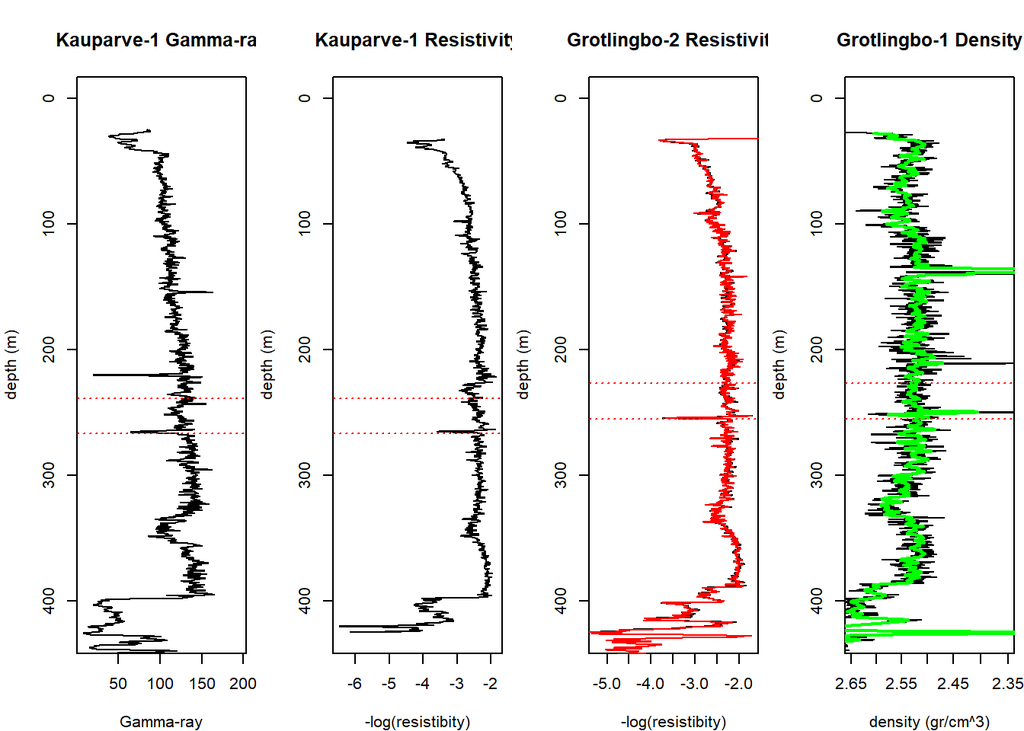

```r
library(lasr)

# Define the exact file path and construct the raw URL
file_path_in_repo <- "SI_4_logs_used/logs_SI_2/GROTLINGBO-1/GROTLINGBO-1_FDC_Sc23427-2851.las"
las_url <- paste0("https://raw.githubusercontent.com/stratigraphy/DTW-Gotland/main/", file_path_in_repo)
temp_file <- tempfile(fileext = ".las")
download.file(url = las_url, destfile = temp_file, mode = "wb")
las <- read.las(temp_file)
GB_1_log <- as.data.frame(las$log$log.1$data)



file_path_in_repo <- "SI_4_logs_used/logs_SI_2/GRÖTLINGBO-2/Sc23427-2219.las"
las_url <- paste0("https://raw.githubusercontent.com/stratigraphy/DTW-Gotland/main/", file_path_in_repo)
temp_file <- tempfile(fileext = ".las")
download.file(url = las_url, destfile = temp_file, mode = "wb")
las <- read.las(temp_file)
GB_2_log <- cbind(las$log$log.1$data[[1]],las$log$log.1$data[[2]])

# Read and process Kauparve_1_RES
Kauparve_1_RES <- read.csv("https://raw.githubusercontent.com/stratigraphy/DTW-Gotland/main/SI_4_logs_used/logs_SI_2/Kauparve_1_RES.csv")
Kauparve_1_RES <- Kauparve_1_RES[, c(2, 3)]

invisible(capture.output({
  Kauparve_1_RES <- sortNave(Kauparve_1_RES, genplot = FALSE, verbose = FALSE)
}))
Kauparve_1_RES <- Kauparve_1_RES[Kauparve_1_RES[, 1] < 425, ]

# Read and process Grotlingbo_2_Res
Grotlingbo_2_Res <- read.csv("https://raw.githubusercontent.com/stratigraphy/DTW-Gotland/main/SI_4_logs_used/logs_SI_2/Grotlingbo_2_Res_2.csv")
Grotlingbo_2_Res <- Grotlingbo_2_Res[, c(2, 3)]

invisible(capture.output({
  Grotlingbo_2_Res <- sortNave(Grotlingbo_2_Res, genplot = FALSE, verbose = FALSE)
}))
Grotlingbo_2_Res <- Grotlingbo_2_Res[Grotlingbo_2_Res[, 1] < 425, ]

invisible(capture.output({
  Grotlingbo_2_Res <- linterp(Grotlingbo_2_Res, dt = 0.1, genplot = FALSE, verbose = FALSE)
}))

# Read and process Kauparve_1_GR
Kauparve_1_GR <- read.csv(
  "https://raw.githubusercontent.com/stratigraphy/DTW-Gotland/main/SI_4_logs_used/OPAB_Digitized/KAUPARVE_1_GR.TXT",
  sep = "\t"
)
invisible(capture.output({
  Kauparve_1_GR <- sortNave(Kauparve_1_GR, genplot = FALSE, verbose = FALSE)
}))


layout.matrix <-
  matrix(c(1:4), nrow = 1, ncol = 4)

layout(layout.matrix,
       heights = c(1, 1, 1,1),
       widths = c(1, 1, 1,1))

par(mar = c(4, 4, 4, 0.5))

plot(
  Kauparve_1_GR[, 2],
  Kauparve_1_GR[, 1],
  type = "l",
  ylim = c(425, 0),
  main = "Kauparve-1 Gamma-ray",
  ylab = "depth (m)",
  xlab = "Gamma-ray"
)
abline(h = 267, lty = 3, col = "red")
abline(h = 239, lty = 3, col = "red")

plot(
  -log(Kauparve_1_RES[, 2]),
  Kauparve_1_RES[, 1],
  type = "l"
  ,
  ylim = c(425, 0),
  main = "Kauparve-1 Resistivity",
  ylab = "depth (m)",
  xlab = "-log(resistibity)"
)
abline(h = 267, lty = 3, col = "red")
abline(h = 239, lty = 3, col = "red")


plot(
  -log(Grotlingbo_2_Res[, 2]),
  Grotlingbo_2_Res[, 1],
  type = "l"
  ,
  ylim = c(425, 0),
  main = "Grotlingbo-2 Resistivity",
  ylab = "depth (m)",
  xlab = "-log(resistibity)"
)
lines(-log(GB_2_log[,2]),GB_2_log[,1],col="red")

abline(h = 255, lty = 3, col = "red")
abline(h = 227, lty = 3, col = "red")

plot(
  GB_1_log[, 3],
  GB_1_log[, 1],
  type = "l"
  ,log="x",
  ylim = c(425, 0),
  xlim=c(2.65,2.35),
  main = "Grotlingbo-1 Density",
  ylab = "depth (m)",
  xlab = "density (gr/cm^3)")

dens_mean <- mwStats(cbind(GB_1_log[, 1],GB_1_log[, 3]),genplot=F, win=2,verbose = F)

lines(dens_mean[,2],dens_mean[,1],col="green",lwd=2)

abline(h = 255, lty = 3, col = "red")
abline(h = 227, lty = 3, col = "red")
```

## References

Aldridge, R.J., Jeppsson, L., and Dorning, K.J., 1993, Early Silurian oceanic episodes and events: Journal - Geological Society (London), v. 150, p. 501–513, doi:10.1144/gsjgs.150.3.0501.

Baarli, G.B., Johnson, M.E., and Antoshkina, A.I., 2003, Silurian stratigraphy and paleogeography of Baltica: May 2014, v. 493, 3–34 p.

Baville, P., Apel, M., Hoth, S., Knaust, D., Antoine, C., Carpentier, C., and Caumon, G., 2022, Computer-assisted stochastic multi-well correlation: Sedimentary facies versus well distality: Marine and Petroleum Geology, v. 135, doi:10.1016/j.marpetgeo.2021.105371.

Biebesheimer, E.J., Cramer, B.D., Calner, M., Barnett, B.A., Oborny, S.C., and Bancroft, A.M., 2021, Asynchronous δ13Ccarb and δ13Corg records during the onset of the Mulde (Silurian) positive carbon isotope excursion from the Altajme core, Gotland, Sweden: Chemical Geology, v. 576, p. 120256, doi:10.1016/j.chemgeo.2021.120256.

Bjerkéus, M., and Eriksson, M., 2001, Late silurian reef development in the baltic sea: Gff, v. 123, p. 169–179, doi:10.1080/11035890101233169.

Bowman, C.N., Young, S.A., Kaljo, D., Eriksson, M.E., Them, T.R., Hints, O., Martma, T., and Owens, J.D., 2019, Linking the progressive expansion of reducing conditions to a stepwise mass extinction event in the late Silurian oceans: Geology, v. 47, p. 968–972, doi:10.1130/G46571.1.

Calner, M., 2005a, A Late Silurian extinction event and anachronistic period: Geology, v. 33, p. 305–308, doi:10.1130/G21185.1.

Calner, M., 2005b, Silurian carbonate platforms and extinction events - Ecosystem changes exemplified from Gotland, Sweden: Facies, v. 51, p. 584–591, doi:10.1007/s10347-005-0050-0.

Calner, M., 2008, Silurian global events - At the tipping point of climate change: Mass Extinction, p. 21–57, doi:10.1007/978-3-540-75916-4_4.

Calner, M., and Eriksson, M.J., 2006a, Evidence for rapid environmental changes in low latitudes during the Late Silurian Lau Event: The Burgen-1 drillcore, Gotland, Sweden: Geological Magazine, v. 143, p. 15–24, doi:10.1017/S001675680500169X.

Calner, M., and Eriksson, M.E., 2006b, Silurian research at the crossroads: Gff, v. 128, p. 73–74, doi:10.1080/11035890601282073.

Calner, M., and Jeppsson, L., 2003, Carbonate platform evolution and conodont stratigraphy during the middle Silurian Mulde Event, Gotland, Sweden: Geological Magazine, v. 140, p. 173–203, doi:10.1017/S0016756802007070.

Calner, M., Jeppsson, L., and Munnecke, A., 2004a, The Silurian of Gotland - Part I: Review of the stratigraphic framework, event stratigraphy, and stable carbon and oxygen isotope development: Erlanger geologische Abhandlungen, v. 5, p. 113–131.

Calner, M., Kozłowska, A., Masiak, M., and Schmitz, B., 2006, A shoreline to deep basin correlation chart for the middle Silurian coupled extinction-stable isotopic event: Gff, v. 128, p. 79–84, doi:10.1080/11035890601282079.

Calner, M., Munnecke, A., and Jeppsson, L., 2004b, The Silurian of Gotland - Part II: Guide to the IGCP 503 field meeting 2004: Erlanger geologischen Abhandlungen, v. 5, p. 20.

Claussen, A.L., 2024, Benthic response to the strong Silurian climatic uctuations-implications from Gotland (Sweden): Facies, doi:10.1007/s10347-024-00686-x.

Cramer, B.D., 2009, Application of Integrated High-Resolution Biochemostratigraphy to Paleozoic Chronostratigraphic Correlation: Recalibrating the Silurian System:, http://rave.ohiolink.edu/etdc/view?acc_num=osu1245178129.

Cramer, B.D., Kleffner, M.A., Brett, C.E., McLaughlin, P.I., Jeppsson, L., Munnecke, A., and Samtleben, C., 2010, Paleobiogeography, high-resolution stratigraphy, and the future of Paleozoic biostratigraphy: Fine-scale diachroneity of the Wenlock (Silurian) conodont Kockelella walliseri: Palaeogeography, Palaeoclimatology, Palaeoecology, v. 294, p. 232–241, doi:10.1016/j.palaeo.2010.01.002.

Dahlqvist, P., Calner, M., Kallaste, T., Kiipli, T., and Siir, S., 2012, Geochemical variations within the mid-Silurian Grötlingbo Bentonite (Gotland, Sweden): Discriminating between magmatic composition, ash transport fractionation and diagenetic effects: Gff, v. 134, p. 273–282, doi:10.1080/11035897.2012.759147.

De Bruin, G., Hemstra, N., and Pouwel, A., 2007, Stratigraphic surfaces in the depositional and chronostratigraphic (Wheeler-transformed) domain: Leading Edge (Tulsa, OK), v. 26, p. 883–886, doi:10.1190/1.2756868.

Edwards, J., Lallier, F., Caumon, G., and Carpentier, C., 2018, Uncertainty management in stratigraphic well correlation and stratigraphic architectures: A training-based method: Computers and Geosciences, v. 111, p. 1–17, doi:10.1016/j.cageo.2017.10.008.

Ellis, D.V., and Singer, J.M., 2007, Well Logging for Earth Scientists: 9, v. 53, 1–30 p., doi:10.1007/978-1-4020-4602-5.

Eriksson, M.J., and Calner, M., 2008, A sequence stratigraphical model for the Late Ludfordian (Silurian) of Gotland, Sweden: Implications for timing between changes in sea level, palaeoecology, and the global carbon cycle: Facies, v. 54, p. 253–276, doi:10.1007/s10347-007-0128-y.

Erlström, M., and Sopher, D., 2019, Geophysical well log-motifs, lithology, stratigraphical aspects and correlation of the Ordovician succession in the Swedish part of the Baltic Basin: International Journal of Earth Sciences, v. 108, p. 1387–1407, doi:10.1007/s00531-019-01712-y.

Erlström, M., Sopher, D., and Dahlqvist, P., 2022, Berggrunden på Sudret, Gotland. Underlag för bedömning av grundvattentillgångar, geoenergipotential samt koldioxidlagring:, www.sgu.se.

Fang, J.H., Chen, H.C., Shultz, A.W., and Mahmoud, W., 1992, Computer-aided well log correlation: American Association of Petroleum Geologists Bulletin, v. 76, p. 307–317, doi:10.1306/bdff87e0-1718-11d7-8645000102c1865d.

Flodén, T., Bjerkéus, M., Tuuling, I., and Eriksson, M., 2001, A silurian reefal succession in the gotland area, baltic sea: Gff, v. 123, p. 137–152, doi:10.1080/11035890101233137.

Frýda, J., Lehnert, O., Joachimski, M.M., Männik, P., Kubajko, M., Mergl, M., Farkaš, J., and Frýdová, B., 2021, The Mid-Ludfordian (late Silurian) Glaciation: A link with global changes in ocean chemistry and ecosystem overturns: Earth-Science Reviews, v. 220, p. 103652, doi:10.1016/j.earscirev.2021.103652.

Giorgino, T., 2009, Computing and visualizing dynamic time warping alignments in R: The dtw package: Journal of Statistical Software, v. 31, p. 1–24, doi:10.18637/jss.v031.i07.

Grant, C.W., Bashore, W.M., and Compton, S., 2018, Rapid Reservoir Modeling with Automated Tops Correlation, *in* Proceedings of the 6th Unconventional Resources Technology Conference, Tulsa, OK, USA, American Association of Petroleum Geologists, doi:10.15530/urtec-2018-2904037.

Hartke, E.R., Cramer, B.D., Calner, M., Melchin, M.J., Barnett, B.A., Oborny, S.C., and Bancroft, A.M., 2021, Decoupling δ13Ccarb and δ13Corg at the onset of the Ireviken Carbon Isotope Excursion: Δ13C and organic carbon burial (forg) during a Silurian oceanic anoxic event: Global and Planetary Change, v. 196, p. 103373, doi:10.1016/j.gloplacha.2020.103373.

Hay, C.C., Creveling, J.R., Hagen, C.J., Maloof, A.C., and Huybers, P., 2019, A library of early Cambrian chemostratigraphic correlations from a reproducible algorithm: Geology, v. 47, p. 457–460, doi:10.1130/G46019.1.

Hladil, J., Vondra, M., Cejchan, P., Vich, R., Koptikova, L., and Slavik, L., 2010, The dynamic time-warping approach to comparison of magnetic-susceptibility logs and application to lower devonian calciturbidites (Prague Synform, Bohemian Massif): Geologica Belgica, v. 13, p. 385–406.

Jeppsson, L., 1987, Lithological and conodont distributional evidence for episodes of anomalous oceanic conditions during the Silurian, *in* Palaeobiology of conodonts., p. 12–145.

Jeppsson, L., 1996, Recognition of a probable secundo–primo event in the Early Silurian: Lethaia, v. 29, p. 311–315, doi:10.1111/j.1502-3931.1996.tb01666.x.

Jeppsson, L., 1998, Silurian oceanic events. Summary of general characteristics, *in* New York State Museum Bulletin, p. 239–257.

Jeppsson, L., and Aldridge, R.J., 2000, Ludlow (late Silurian) oceanic episodes and events: Journal of the Geological Society, v. 157, p. 1137–1148, doi:10.1144/jgs.157.6.1137.

Jeppsson, L., Aldridge, R.J., and Dorning, K.J., 1995, Wenlock (Silurian) oceanic episodes and events: Journal - Geological Society (London), v. 152, p. 487–498, doi:10.1144/gsjgs.152.3.0487.

Jeppsson, L., and Calner, M., 2002, The silurian mulde event and a scenario for secundo-secundo events: Transactions of the Royal Society of Edinburgh, Earth Sciences, v. 93, p. 135–154, doi:10.1017/S0263593300000377.

Jeppsson, L., Eriksson, M.E., and Calner, M., 2006, A latest Llandovery to latest Ludlow high-resolution biostratigraphy based on the Silurian of Gotland - a summary: Gff, v. 128, p. 109–114, doi:10.1080/11035890601282109.

Jorgensen, F. et al., 2018, A 3D geological model of the Island of Gotland based on extensive airborne EM mapping , seismic data and log stratigraphy A 3D geological model of the Island of Gotland based on extensive airborne EM mapping , seismic data and log stratigraphy .: EAM2018 7th International Workshop on Airborne Electromagnetics, p. 1–4.

Lallier, F., Caumon, G., Borgomano, J., Viseur, S., Fournier, F., Antoine, C., and Gentilhomme, T., 2012, Relevance of the stochastic stratigraphic well correlation approach for the study of complex carbonate settings: Application to the Malampaya buildup (Offshore Palawan, Philippines): Geological Society Special Publication, v. 370, p. 265–275, doi:10.1144/SP370.12.

Lallier, F., Caumon, G., Borgomano, J., Viseur, S., Royer, J.J., and Antoine, C., 2016, Uncertainty assessment in the stratigraphic well correlation of a carbonate ramp: Method and application to the Beausset Basin, SE France: Comptes Rendus - Geoscience, v. 348, p. 499–509, doi:10.1016/j.crte.2015.10.002.

Lazauskiene, J., Sliaupa, S., Brazauskas, A., and Musteikis, P., 2003, Sequence stratigraphy of the Baltic Silurian succession: Tectonic control on the foreland infill: Geological Society Special Publication, v. 208, p. 95–115, doi:10.1144/GSL.SP.2003.208.01.05.

Levendal, T., Sopher, D., Juhlin, C., and Lehnert, O., 2019, Investigation of an Ordovician carbonate mound beneath Gotland, Sweden, using 3D seismic and well data: Journal of Applied Geophysics, v. 162, p. 22–34, doi:10.1016/j.jappgeo.2019.01.008.

Lineman, D., Mendelson, J., and Toksoz, M., 1987, Well to well log correlation using knowledgebased systems and dynamic depth warping: Transactions of SPWLA 28th Annual Logging Symposium, p. 1–25.

Lomask, J., Francis, J.M., Rickett, J., Buursink, M.L., Gerber, T.P., Perlmutter, M., and Paola, C., 2009, New tools for seismic stratigraphie interpretation: Strata! Convergence and instantaneous isochron attribute cubes derived from volumetric flattening of experimental strata: AAPG Bulletin, v. 93, p. 453–459, doi:10.1306/11200808104.

Männik, P., Loydell, D.K., Nestor, V., and Nõlvak, J., 2015, Integrated Upper Ordovician–lower Silurian biostratigraphy of the Grötlingbo-1 core section, Sweden: Gff, v. 137, p. 226–244, doi:10.1080/11035897.2015.1042032.

Manten, A.A., 1971, Silurian Reefs of Gotland: Developments in Sedimentology, p. 539, doi:10.1017/S0016756800056922.

McLaughlin, P.I., Emsbo, P., Brett, C.E., Bancroft, A.M., Desrochers, A., and Vandenbroucke, T.R.A., 2019, The rise of pinnacle reefs: A step change in marine evolution triggered by perturbation of the global carbon cycle: Earth and Planetary Science Letters, v. 515, p. 13–25, doi:10.1016/j.epsl.2019.02.039.

Melchin, M.J., Sadler, P.M., and Cramer, B.D., 2020, The Silurian Period (F. M. Gradstein, J. G. Ogg, M. D. Schmitz, & G. M. Ogg, Eds.): BV, 695–732 p., doi:10.1016/B978-0-12-824360-2.00021-8.

Melchin, M.J., Sadler, P.M., Cramer, B.D., Cooper, R.A., Gradstein, F.M., and Hammer, Ø., 2005, The silurian period (F. M. Gradstein, J. G. Ogg, M. D. Schmitz, & G. M. Ogg, Eds.): Elsevier, 188–201 p., doi:10.1016/B978-0-444-59425-9.00021-4.

Meyers, S.R., 2019, Cyclostratigraphy and the problem of astrochronologic testing: Earth-Science Reviews, v. 190, p. 190–223, doi:10.1016/j.earscirev.2018.11.015.

Nieminski, N.M., Sylvester, Z., Covault, J.A., Gomberg, J., Staisch, L., and McBrearty, I.W., 2024, Turbidite correlation for paleoseismology: Geological Society of America Bulletin, p. 1–12, doi:10.1130/b37343.1.

Petitjean, F., Ketterlin, A., and Gançarski, P., 2011, A global averaging method for dynamic time warping, with applications to clustering: Pattern Recognition, v. 44, p. 678–693, doi:10.1016/j.patcog.2010.09.013.

Qayyum, F., Catuneanu, O., and de Groot, P., 2015, Historical developments in Wheeler diagrams and future directions: Basin Research, v. 27, p. 336–350, doi:10.1111/bre.12077.

Radzevicius, S., 2014, Pristiograptus ( Graptoloidea ) from the Upper Wenlock S . Radzevi c ius * and J . Pa s kevi c ius **:

Rose, C.V., Fischer, W.W., Finnegan, S., and Fike, D.A., 2019, Records of carbon and sulfur cycling during the Silurian Ireviken Event in Gotland, Sweden: Geochimica et Cosmochimica Acta, v. 246, p. 299–316, doi:10.1016/j.gca.2018.11.030.

Samtleben, C., Munnecke, A., and Bickert, T., 2000, Development of facies and C/O-isotopes in transects through the Ludlow of Gotland: Evidence for global and local influences on a shallow-marine environment: Facies, v. 43, p. 1–38, doi:10.1007/bf02536983.

Sardá-Espinosa, A., 2019, Time-series clustering in R Using the dtwclust package: R Journal, v. 11, p. 1–45, doi:10.32614/rj-2019-023.

Sopher, D., Erlström, M., Bell, N., and Juhlin, C., 2016, The structure and stratigraphy of the sedimentary succession in the Swedish sector of the Baltic Basin: New insights from vintage 2D marine seismic data: Tectonophysics, v. 676, p. 90–111, doi:10.1016/j.tecto.2016.03.012.

Stolfus, B.M., Allman, L.J., Young, S.A., Calner, M., Hartke, E.R., Oborny, S.C., Bancroft, A.M., and Cramer, B.D., 2023, Expansion of Reducing Marine Environments During the Ireviken Biogeochemical Event: Evidence From the Altajme Core, Gotland, Sweden: Paleoceanography and Paleoclimatology, v. 38, doi:10.1029/2022PA004484.

Sylvester, Z., 2023, Automated multi‐well stratigraphic correlation and model building using relative geologic time: Basin Research, v. 35, p. 1961–1984, doi:10.1111/bre.12787.

Tuuling, I., and Flodén, T., 2013, Silurian reefs off Saaremaa and their extension towards Gotland, central Baltic Sea: Geological Magazine, v. 150, p. 923–936, doi:10.1017/S0016756813000101.

Tuuling, I., and Flodén, T., 2009, The Llandovery-lowermost Wenlock sequence in the Baltic Sea between Saaremaa and Gotland; subdivision, thicknesses and correlation, based on marine seismic studies: Marine Geology, v. 267, p. 55–70, doi:10.1016/j.margeo.2009.09.004.

Vandenbroucke, T.R.A., Munnecke, A., Leng, M.J., Bickert, T., Hints, O., Gelsthorpe, D., Maier, G., and Servais, T., 2013, Reconstructing the environmental conditions around the Silurian Ireviken Event using the carbon isotope composition of bulk and palynomorph organic matter: Geochemistry, Geophysics, Geosystems, v. 14, p. 86–101, doi:10.1029/2012GC004348.

Wheeler, L., 2015, Automatic and simultaneous correlation of multiple well logs: M.S. Thesis. Colorado School of Mines, p. 40.

Wheeler, L., and Hale, D., 2014, Simultaneous correlation of multiple well logs: Society of Exploration Geophysicists International Exposition and 84th Annual Meeting SEG 2014, p. 618–622, doi:10.1190/segam2014-0227.1.

Wu, X., Li, Y., and Sawasdee, P., 2022, Toward accurate seismic flattening: Methods and applications: GEOPHYSICS, v. 87, p. IM177–IM188, doi:10.1190/geo2021-0662.1.

Wu, X., Shi, Y., Fomel, S., and Li, F., 2018, Incremental correlation of multiple well logs following geologically optimal neighbors: Interpretation, v. 6, p. T713–T722, doi:10.1190/INT-2018-0020.1.

Younes, H., Calner, M., and Lehnert, O., 2017, The first continuous δ13C record across the Late Silurian Lau Event on Gotland, Sweden: Gff, v. 139, p. 63–69, doi:10.1080/11035897.2016.1227362.

Zoraster, S., Paruchuri, R., and Darby, S., 2004, Curve Alignment for Well-to-Well Log Correlation, *in* SPE Annual Technical Conference and Exhibition, SPE, doi:10.2118/90471-MS.